# Device-independent bit commitment based on the CHSH inequality

English original + Chinese translation / 英中逐段对照

# Device-independent bit commitment based on the CHSH inequality / 基于 CHSH 不等式的设备无关比特承诺

This bilingual edition pairs each English paragraph of Aharon, Massar, Pironio, and Silman, *New J. Phys.* **18**, 025014 (2016) with a Chinese translation. Citation numbers follow the published article, [1]–[48]. Formulas are kept in LaTeX.

本双语版将 Aharon、Massar、Pironio 与 Silman 发表于 *New J. Phys.* **18**, 025014 (2016) 的论文逐段英中对照。引用编号与正式发表文本 [1]–[48] 一致。公式保留 LaTeX。

The English text follows the published NJP article; where the 2015 arXiv source differs (notably the comparison with relativistic bit commitment), the NJP wording is used. Bibliographic fields are left in English.

英文以 NJP 正式发表稿为准；当 2015 年 arXiv 稿与之不同时（尤其是与相对论比特承诺的比较），采用 NJP 表述。参考文献著录项保持英文。

# Device-Independent Bit Commitment based on the CHSH Inequality / 基于 CHSH 不等式的设备无关比特承诺

**English original**

N. Aharon<sup>1,2</sup>, S. Massar<sup>3</sup>, S. Pironio<sup>3</sup>, and J. Silman<sup>3</sup>

**中文译文**

N. Aharon<sup>1,2</sup>、S. Massar<sup>3</sup>、S. Pironio<sup>3</sup> 和 J. Silman<sup>3</sup>

**English original**

Affiliation: <sup>1</sup>School of Physics and Astronomy, Tel-Aviv University, Tel-Aviv 69978, Israel; <sup>2</sup>Racah Institute of Physics, The Hebrew University of Jerusalem, Jerusalem 91904, Israel; <sup>3</sup>Laboratoire d’Information Quantique, Université Libre de Bruxelles (ULB), 1050 Bruxelles, Belgium

**中文译文**

单位：<sup>1</sup>以色列特拉维夫大学物理与天文学学院，特拉维夫 69978；<sup>2</sup>以色列耶路撒冷希伯来大学拉卡物理研究所，耶路撒冷 91904；<sup>3</sup>比利时布鲁塞尔自由大学（ULB）量子信息实验室，布鲁塞尔 1050

**English original**

*New J. Phys.* **18**, 025014 (2016); doi:10.1088/1367-2630/18/2/025014; [arXiv:1511.06283](https://arxiv.org/abs/1511.06283).

**中文译文**

《新物理学杂志》**18**, 025014 (2016)；doi:10.1088/1367-2630/18/2/025014；[arXiv:1511.06283](https://arxiv.org/abs/1511.06283)。

## Abstract / 摘要

**English original**

Bit commitment and coin flipping occupy a unique place in the device-independent landscape, as the only device-independent protocols thus far suggested for these tasks are reliant on tripartite GHZ correlations. Indeed, we know of no other bipartite tasks, which admit a device-independent formulation, but which are not known to be implementable using only bipartite nonlocality. Another interesting feature of these protocols is that the pseudo-telepathic nature of GHZ correlations – in contrast to the generally statistical character of nonlocal correlations, such as those arising in the violation of the CHSH inequality – is essential to their formulation and analysis. In this work, we present a device-independent bit commitment protocol based on CHSH testing, which achieves the same security as the optimal GHZ-based protocol. The protocol is analyzed in the most general settings, where the devices are used repeatedly and may have long-term quantum memory. We also recast the protocol in a post-quantum setting where both honest and dishonest parties are restricted only by the impossibility of signaling, and find that overall the supra-quantum structure allows for greater security.

**中文译文**

比特承诺（bit commitment）与抛硬币（coin flipping）在设备无关（device-independent）研究图景中占据独特地位，因为迄今为这些任务提出的设备无关协议都依赖三方 GHZ 关联。事实上，我们不知道还有其他这样的双方任务：它们可以采用设备无关表述，却尚不知能否仅利用双方非定域性来实现。这些协议的另一个有趣特征是，GHZ 关联的伪心灵感应（pseudo-telepathic）性质——不同于非定域关联通常所具有的统计性质，例如违反 CHSH 不等式时产生的关联——对协议的构造与分析至关重要。在本文中，我们提出一种基于 CHSH 测试的设备无关比特承诺协议，它达到了最优 GHZ 协议同等的安全性。我们在最一般的情形下分析该协议，其中设备会被反复使用，并且可能具有长期量子存储器。我们还在后量子（post-quantum）情形下重新表述该协议；在这一情形中，无论诚实方还是不诚实方都仅受不可信号传递原则约束，并发现总体而言，超量子结构能够提供更高的安全性。

## I Introduction / I 引言

**English original**

The security of cryptographic protocols, whether quantum or classical, depends on the satisfaction of certain assumptions. These include the integrity of each party’s lab and their having a trusted source of randomness to make the random choices called for by the protocol. Beyond these, classical protocols will also usually include assumptions regarding the computational power of dishonest parties. The security of quantum protocols, in contrast, is based only on the validity of quantum theory. Nevertheless, to harness this validity, assumptions regarding the implementation must be made. Most protocols make many such assumptions, including regarding the internal workings of the devices used in the implementation, e.g. specifying the Hilbert space dimension of the quantum systems used and the bases of the measurements performed. Protocols of this type are said to be device-dependent. Clearly, it is desirable to base security on a minimum number of assumptions, as this facilitates its evaluation. The aim of the device-independent approach to quantum cryptography [1, 2] is to do just that by doing away with a maximum number of assumptions regarding the implementation.

**中文译文**

无论量子还是经典密码协议，其安全性都依赖若干假设得到满足。这些假设包括各方实验室的完整性，以及各方拥有可信随机源，以作出协议所要求的随机选择。除此之外，经典协议通常还会包含关于不诚实方计算能力的假设。相比之下，量子协议的安全性仅以量子理论的有效性为基础。然而，要利用这种有效性，就必须对具体实现作出假设。大多数协议都会作出许多此类假设，其中包括对实现所用设备内部工作机制的假设，例如规定所用量子系统的希尔伯特空间维数和所执行测量的基。此类协议被称为设备依赖（device-dependent）协议。显然，安全性所依据的假设越少越好，因为这样更便于评估安全性。量子密码学设备无关方法 [1, 2] 的目标正是尽可能摒除有关实现的假设。

**English original**

More specifically, a cryptographic protocol is said to be device-independent if its security can be guaranteed without making assumptions about the internal workings of the devices used in its implementation. This can be achieved by carrying out Bell tests on entangled systems. The level of security is then deduced from the observed amount of nonlocality. In particular, each device is treated as a black box with knobs and registers for selecting and displaying (classical) inputs and outputs. For instance, in device-independent quantum key-distribution a high violation of the CHSH inequality [3] guarantees that an eavesdropper will have no information about the (post-processed) key [2, 4, 5, 6, 7, 8, 9, 10]. In contrast, in the (device-dependent) entanglement-based version of the BB84 protocol it has been shown that if the source dispenses qudits instead of qubits then security can be utterly compromised [11, 12]. Indeed, recent hacking attacks on quantum key-distribution systems, such as those of [13, 14], exploit device-dependent modes of failure and would not be successful in device-independent settings.

**中文译文**

更具体地说，如果无须对实现协议所用设备的内部工作机制作出假设就能保证协议安全，那么该密码协议就称为设备无关协议。这可以通过对纠缠系统执行贝尔测试（Bell test）来实现，随后根据观测到的非定域性大小推断安全程度。具体而言，每台设备都被视为一个黑箱，带有用于选择和显示（经典）输入与输出的旋钮和寄存器。例如，在设备无关量子密钥分发中，对 CHSH 不等式 [3] 的高度违反可保证窃听者无法获得关于（后处理）密钥的任何信息 [2, 4, 5, 6, 7, 8, 9, 10]。相比之下，已有研究表明，在（设备依赖的）基于纠缠的 BB84 协议版本中，如果信号源发放的是量子多能级系统而非量子比特，安全性就可能彻底遭到破坏 [11, 12]。事实上，近期针对量子密钥分发系统的黑客攻击，例如 [13, 14] 中的攻击，利用的正是设备依赖型失效模式；在设备无关情形下，这些攻击不会成功。

**English original**

In addition to quantum key-distribution, device-independent protocols have been introduced for diverse tasks such as randomness generation [15, 16, 17, 18, 19, 20, 21], the self-testing of quantum computers [1, 11, 22, 8], state estimation [23, 24, 25, 26, 27], genuine multipartite entanglement certification [28], and entanglement quantification [29]. However, until recently it was not known whether the scope of the device-independent approach also covers protocols in the distrustful cryptography class, where the parties do not trust each other and may have conflicting goals. Problems in this class present us with an extra challenge in device-independent settings as compared to tasks such as quantum-key distribution. Namely, how to allow remote distrustful parties to certify the presence of nonlocality without collaborating. In [30] it was shown that imperfect bit commitment<sup>1</sup> admits a device-independent formulation, and, since bit commitment may serve as a primitive for coin flipping, so does coin flipping (a device-independent coin flipping protocol, not based on bit commitment, was also introduced in [35]). Whether these results extend to all problems in the distrustful cryptography class remains an open question.

**中文译文**

除量子密钥分发之外，人们还针对多种任务提出了设备无关协议，例如随机数生成 [15, 16, 17, 18, 19, 20, 21]、量子计算机自测试 [1, 11, 22, 8]、量子态估计 [23, 24, 25, 26, 27]、真正多方纠缠认证 [28] 和纠缠量化 [29]。然而，直到最近，人们仍不知道设备无关方法的适用范围是否也涵盖互不信任密码学（distrustful cryptography）这一类协议；在这类协议中，各方互不信任，并且目标可能相互冲突。与量子密钥分发等任务相比，这一类问题在设备无关情形下带来了额外挑战，即如何让彼此不信任的远程参与方在不合作的情况下认证非定域性的存在。[30] 表明，不完美比特承诺<sup>1</sup>可以采用设备无关表述；又因为比特承诺可以作为抛硬币的密码学原语，所以抛硬币同样可以采用设备无关表述（[35] 还提出了一种不基于比特承诺的设备无关抛硬币协议）。这些结果能否推广到互不信任密码学类的所有问题，仍是一个开放问题。

**English original**

A notable feature of the protocols of [30, 35] is that they are based on GHZ correlations [36, 37]. Indeed, bit commitment and coin flipping are the only examples we have of bipartite tasks, which admit a device-independent formulation, but which are not known to admit one based on CHSH testing (i.e. sequential tests of the CHSH inequality), or, more generally, on some other bipartite Bell inequality testing. This is especially interesting in light of Reichardt et al.’s recent demonstration [8] that CHSH testing can provide the basis for many device-independent applications in the most general settings where the devices have long-term quantum memory.

**中文译文**

[30, 35] 中协议的一个显著特征是，它们以 GHZ 关联 [36, 37] 为基础。事实上，在我们已知的双方任务实例中，只有比特承诺和抛硬币可以采用设备无关表述，却尚不知能否采用基于 CHSH 测试（即对 CHSH 不等式的序贯测试）的设备无关表述，或者更一般地，采用基于其他双方贝尔不等式测试的设备无关表述。Reichardt 等人最近证明 [8]，在设备具有长期量子存储器这一最一般情形下，CHSH 测试可以作为许多设备无关应用的基础；鉴于这一结果，上述现象尤其值得关注。

**English original**

In [30, 35], the pseudo-telepathic nature of GHZ correlations is exploited to circumvent the unique difficulties associated with distrustful cryptography, specifically, the fact that different parties have conflicting goals and do not trust each other. Quantum pseudo-telepathy is the term coined for the phenomenon of always winning in nonlocal games, which classically (i.e. without sharing entanglement) can only be won part of the time. A famous example is the GHZ game [38]. In particular, pseudo-telepathy entails perfect correlations. In [30] pseudo-telepathy is used to allow Bob to verify the presence of nonlocal correlations (GHZ correlations) and at the same time to verify Alice’s commitment (that the token of her commitment is consistent with the value of the bit she reveals). Crucially, Bob uses the same measurements to verify both the presence of nonlocality and the commitment.

**中文译文**

在 [30, 35] 中，研究者利用 GHZ 关联的伪心灵感应性质，规避互不信任密码学特有的困难，尤其是不同参与方目标相互冲突且彼此不信任这一事实。“量子伪心灵感应”（quantum pseudo-telepathy）一词指的是这样一种现象：在非定域博弈中总能获胜，而在经典情形下（即不共享纠缠时）只能在部分情况下获胜。GHZ 博弈 [38] 是一个著名例子。特别地，伪心灵感应意味着完美关联。在 [30] 中，伪心灵感应使 Bob 能够验证非定域关联（GHZ 关联）的存在，同时验证 Alice 的承诺（即她的承诺凭据与她所揭示的比特值一致）。关键在于，Bob 使用同一组测量来同时验证非定域性的存在和承诺。

**English original**

Unfortunately, pseudo-telepathy is absent in the CHSH setting [39], and so it is a priori unclear whether bipartite distrustful cryptographic tasks can be based on CHSH testing – which is the case for all other examples of bipartite tasks that are known to admit a device-independent formulation. Beyond a theoretical interest, this question is also practically motivated, since manipulating tripartite entanglement, as would be required in a GHZ-based protocol, is obviously more difficult than manipulating EPR pairs, as would be required in a CHSH-based protocol.

**中文译文**

遗憾的是，CHSH 情形中不存在伪心灵感应 [39]，因此先验上并不清楚双方互不信任密码学任务能否以 CHSH 测试为基础——而对于所有其他已知可采用设备无关表述的双方任务实例，情况正是如此。除了理论意义外，这一问题也有实际动机，因为基于 GHZ 的协议需要操控三方纠缠，这显然比基于 CHSH 的协议所需的 EPR 对更难操控。

**English original**

In this work we present a device-independent bit commitment protocol, based on CHSH testing, which achieves the same security as that of [30]: (In the limit of an infinite number of tests) Alice’s control equals $\cos^{2}(\frac{\pi}{8})\simeq 0.8536$ , while Bob’s information gain equals $0.75$ . This shows that pseudo-telepathy is not only inessential for device-independent distrustful cryptography, but that its absence does not necessarily impact security. Specifically, we show how to guarantee that the devices have no way of telling whether they are used as part of the nonlocality testing phase or the verification of the commitment; this being the crucial element on which security hinges.

**中文译文**

在本文中，我们提出一种基于 CHSH 测试的设备无关比特承诺协议，它达到了与 [30] 相同的安全性：（在测试次数趋于无穷的极限下）Alice 的控制概率等于 $\cos^{2}(\frac{\pi}{8})\simeq 0.8536$，而 Bob 的信息获取概率等于 $0.75$。这表明，对于设备无关的互不信任密码学而言，伪心灵感应不仅不是必不可少的，而且缺少它也未必影响安全性。具体而言，我们说明了如何保证设备无法判断自身是用于非定域性测试阶段，还是用于承诺验证；这正是安全性所依赖的关键要素。

**English original**

Our security analysis covers the case of imperfect devices (i.e. the CHSH inequality is not maximally violated) and is carried out in the most general settings where memory effects (the dependence of a measurement outcome not only on the setting, but also on previous settings and outcomes) are taken into account.

**中文译文**

我们的安全性分析涵盖设备不完美的情形（即 CHSH 不等式未达到最大违反），并且是在把记忆效应纳入考虑的最一般情形下进行的；所谓记忆效应，是指测量结果不仅依赖当前设置，还依赖先前的设置与结果。

**English original**

It should be noted that in our protocol the reveal time is fixed and cannot be chosen at will by Alice. Strictly speaking, the protocol is thus not a bit commitment protocol. Nevertheless, depending on the application, it may still be used as a primitive. For example, our protocol can be used to implement coin flipping. The restriction on the reveal time can be lifted at the price of increasing Alice’s cheating probability (see Appendix B), or by working in the large office scenario where instead of a pair of boxes there are many pairs (see Appendix C).

**中文译文**

应当指出，在我们的协议中，揭示时间是固定的，Alice 不能任意选择。因此，严格来说，该协议并不是比特承诺协议。不过，视具体应用而定，它仍可用作一种密码学原语。例如，我们的协议可用于实现抛硬币。可以通过提高 Alice 的作弊概率（见附录 B）来解除对揭示时间的限制，或者在“大办公室情形”（large office scenario）下工作，即使用多对黑箱而不是一对黑箱（见附录 C）。

**English original**

We also study the problem in a post-quantum world where both dishonest and honest parties are restricted only by the impossibility of signaling. This helps us identify the contribution of different resources to security. On the one hand, we might expect such a world to offer less security since a dishonest party would have access to stronger correlations. On the other hand, we might expect the converse, since the protocol itself could be modified to make use of these stronger correlations (in particular, pseudo-telepathy is restored in this setting). It turns out that on the balance this allows for more security.

**中文译文**

我们还在一个后量子世界中研究这一问题，其中不诚实方和诚实方都只受不可信号传递原则的约束。这有助于我们辨明不同资源对安全性的贡献。一方面，我们可能预期这样的世界安全性更低，因为不诚实方可以利用更强的关联。另一方面，我们也可能预期恰好相反，因为可以修改协议本身以利用这些更强的关联（尤其是伪心灵感应在此情形下得以恢复）。结果表明，总体权衡之下，这使安全性得以提高。

**English original**

The paper is structured as follows. We begin in Section II by defining the problem of bit commitment, and making explicit exactly what we mean by device-independence. Next, in Section III, we present the protocol, followed by the proofs of Alice’s and Bob’s securities in Sections IV and V, respectively. We conclude with a summary in Section VI. In Appendix A we present the post-quantum version of our protocol. Appendices B and C present modifications of the protocol where Alice can freely choose the reveal time.

**中文译文**

本文结构如下。首先，我们在第二节定义比特承诺问题，并明确说明“设备无关”的确切含义。接下来，我们在第三节介绍协议，随后分别在第四节和第五节证明 Alice 与 Bob 的安全性。第六节给出总结。附录 A 介绍协议的后量子版本。附录 B 和附录 C 给出协议的修改版本，在这些版本中 Alice 可以自由选择揭示时间。

## II Background / II 背景

### II.1 Bit commitment / II.1 比特承诺

**English original**

Bit commitment is a cryptographic primitive comprising two remote, distrustful parties. Party $\mathcal{A}$ , usually referred to as Alice, commits a bit to party $\mathcal{B}$ , usually referred to as Bob, such that following her commitment Alice cannot change its value and Bob is unable to learn it until she chooses to reveal it. Classically, if the dishonest party’s computational power is unlimited, they can cheat perfectly. Quantumly, the dishonest party cannot cheat perfectly [33], though perfect bit commitment is still impossible [31, 32].

**中文译文**

比特承诺是一种涉及两个彼此远离且互不信任参与方的密码学原语。参与方 $\mathcal{A}$（通常称为 Alice）向参与方 $\mathcal{B}$（通常称为 Bob）承诺一个比特，使得 Alice 在作出承诺后不能更改其值，而 Bob 在 Alice 选择揭示之前无法得知该值。在经典情形下，如果不诚实方的计算能力不受限制，就能完美作弊。在量子情形下，不诚实方无法完美作弊 [33]，不过完美比特承诺仍然是不可能的 [31, 32]。

**English original**

A bit commitment protocol consists of two phases: the commit phase in which Alice sends Bob some token of her commitment, and the reveal phase in which Alice reveals to Bob the value of the committed bit. The probability with which dishonest Alice is able to control the value of the bit she wants to reveal following the commit phase, without being caught cheating by Bob, is referred to as Alice’s control, which we will denote by $P_{\mathrm{cont}}=\frac{1}{2}(p_{0}+p_{1})$ . Here $p_{0}$ ( $p_{1}$ ) is Alice’s probability of successfully revealing $0$ ( $1$ ) and the factor of $\frac{1}{2}$ is due to the implicit assumption that she is equally likely to wish to reveal $0$ as $1$ . Similarly, dishonest Bob’s probability of correctly learning the value of the bit before the reveal phase is referred to as Bob’s information gain, which we will denote by $P_{\mathrm{gain}}$ . In a perfect bit commitment protocol $P_{\mathrm{cont}}=P_{\mathrm{gain}}=\frac{1}{2}$ . A protocol is said to be balanced if $P_{\mathrm{cont}}=P_{\mathrm{gain}}$ . Quantumly, in any balanced protocol $P_{\mathrm{cont}}=P_{\mathrm{gain}}\gtrsim 0.739$ , with the bound being saturable [34].

**中文译文**

比特承诺协议由两个阶段组成：承诺阶段（commit phase），Alice 在该阶段向 Bob 发送某种承诺凭据；以及揭示阶段（reveal phase），Alice 在该阶段向 Bob 揭示所承诺比特的值。承诺阶段结束后，不诚实的 Alice 在不被 Bob 发现作弊的情况下控制自己想要揭示的比特值的概率，称为 Alice 的控制概率，记作 $P_{\mathrm{cont}}=\frac{1}{2}(p_{0}+p_{1})$。这里，$p_{0}$（$p_{1}$）是 Alice 成功揭示 $0$（$1$）的概率；因隐含假设她想要揭示 $0$ 和 $1$ 的可能性相同，故有因子 $\frac{1}{2}$。类似地，不诚实的 Bob 在揭示阶段之前正确获知比特值的概率，称为 Bob 的信息获取概率，记作 $P_{\mathrm{gain}}$。在完美比特承诺协议中，$P_{\mathrm{cont}}=P_{\mathrm{gain}}=\frac{1}{2}$。如果 $P_{\mathrm{cont}}=P_{\mathrm{gain}}$，则称协议是平衡的。在量子情形下，任何平衡协议均有 $P_{\mathrm{cont}}=P_{\mathrm{gain}}\gtrsim 0.739$，且该界可以达到 [34]。

### II.2 Device-independence / II.2 设备无关性

**English original**

In this subsection we make more concrete exactly what we mean by device-independence. We make the following standard assumptions.

**中文译文**

在本小节中，我们将更具体地说明“设备无关性”（device-independence）的确切含义。我们作出以下标准假设。

1. **English original**

   Alice and Bob have access to boxes, each with a knob for selecting a classical input $s$ and a register for displaying a classical output $r$ . Entering an input always results in an output (i.e. we do not consider losses).

   **中文译文**

   Alice 和 Bob 可以使用若干黑箱，每个黑箱都有一个用于选择经典输入 $s$ 的旋钮和一个用于显示经典输出 $r$ 的寄存器。输入总会产生输出（即我们不考虑损耗）。
2. **English original**

   Alice and Bob, whether honest or dishonest, are restricted by quantum theory.

   **中文译文**

   无论诚实与否，Alice 和 Bob 都受量子理论约束。
3. **English original**

   The boxes may be prevented at will from communicating with one another.

   **中文译文**

   可以根据需要阻止各黑箱彼此通信。
4. **English original**

   Alice and Bob each have a trusted source of randomness.

   **中文译文**

   Alice 和 Bob 各自拥有可信随机源。
5. **English original**

   No information leaks out of an honest party’s lab.

   **中文译文**

   诚实方的实验室不会泄露任何信息。

**English original**

Suppose now that an honest party has a pair of boxes $0$ and $1$ . Assumptions 2 and 3 imply that the probability of outputting $r^{0}$ and $r^{1}$ when inputting $s^{0}$ and $s^{1}$ into boxes $0$ and $1$ , respectively, is given by

$$P\left(r^{0},\,r^{1}|s^{0},\,s^{1}\right)=\mathrm{Tr}\left(\rho\,\Pi_{r^{0}|s^{0}}\otimes\Pi_{r^{1}|s^{1}}\right)\,,
\tag{1}$$

**中文译文**

现在假设某个诚实方拥有编号为 $0$ 和 $1$ 的一对黑箱。由假设 2 和 3 可知，分别向黑箱 $0$ 和 $1$ 输入 $s^{0}$ 和 $s^{1}$ 时，输出 $r^{0}$ 和 $r^{1}$ 的概率由上式给出。

**English original**

where $\rho$ is some joint quantum state and $\Pi_{r^{i}|s^{i}}$ is the POVM element corresponding to inputting $s^{i}$ and outputting $r^{i}$ . This is the only constraint on the boxes’ behavior. Specifically, a dishonest party may choose the state $\rho$ and the POVM elements $\Pi_{r^{i}|s^{i}}$ as best suits them. The boxes may also have internal memories, clocks, gyroscopes, etc., allowing a dishonest party to program them such that their behavior depends on their location, their past trajectories, the time at which inputs are fed, or any other aspect of their past history.

**中文译文**

其中，$\rho$ 是某个联合量子态，$\Pi_{r^{i}|s^{i}}$ 是与输入 $s^{i}$ 并输出 $r^{i}$ 相对应的正算符值测度（POVM）元素。这是对黑箱行为的唯一约束。具体而言，不诚实方可以按最有利于自己的方式选择状态 $\rho$ 和 POVM 元素 $\Pi_{r^{i}|s^{i}}$。黑箱还可以具有内部存储器、时钟、陀螺仪等，从而使不诚实方能够对其进行编程，使其行为依赖于所在位置、以往轨迹、输入被送入的时间，或其过往历史的任何其他方面。

**English original**

In the following, we will consider situations where boxes are sent from one party to the other. By this, it is not meant that actual measurement devices are sent (though it is easier to present and formulate our results in this way). In fact, we do not assume anything beyond Alice and Bob having access to a quantum channel—as is necessarily required in quantum cryptography. What is meant is that whenever a box is sent, quantum information encoding instructions for the measurement devices (as well as the quantum state of the boxes) is exchanged between the parties, such that in an honest execution of the protocol the same state $\rho$ and the POVM elements $\Pi_{r^{i}|s^{i}}$ characterizing the behavior, say, of Alice’s box before the transmission of quantum information, will characterize the behavior of Bob’s box after receiving the transmission.

**中文译文**

下文将考虑把盒子从一方发送给另一方的情形。这并非指实际发送测量设备（尽管以这种方式陈述和表述结果更为方便）。事实上，我们除了假设 Alice 和 Bob 拥有量子信道——这是量子密码学所必需的——之外，不作其他假设。所谓发送盒子，是指每当发送一个盒子时，双方交换编码了测量设备指令的量子信息（以及盒子的量子态），使得在诚实执行协议时，例如，在传输量子信息之前刻画 Alice 盒子行为的同一个状态 $\rho$ 和 POVM 元素 $\Pi_{r^{i}|s^{i}}$，也将刻画 Bob 接收传输之后其盒子的行为。

**English original**

Finally, we wish to comment on the differences in the assumptions underlying our protocol as compared to relativistic bit commitment protocols [40, 41]. Indeed, relativistic causality is by itself sufficient for perfect bit commitment (whether purely classical [40] or quantum [41]), but this comes at the cost of extra resources. In relativistic bit commitment at least one of the parties must be assigned two remote secure labs, which allow for implementing spacelike related measurements. In contrast, in our protocol each party is assigned a single secure lab. Moreover, we do not impose any relativistic constraints. In particular, we do not require any measurements be spacelike related. In fact, many of the measurements in our protocol are not spacelike related. This does not come at the expense of preventing the boxes from communicating (i.e. assumption 3), since spacelike related measurements are not the only way to achieve this. An alternative way, and an experimentally easier one, is simply shield each of the boxes (see [5, 16] for a discussion of this point).

**中文译文**

最后，我们想说明本协议所依据的假设与相对论比特承诺协议 [40, 41] 的差异。的确，相对论因果性本身足以实现完美比特承诺（无论纯经典 [40] 还是量子 [41]），但这需要额外资源。在相对论比特承诺中，至少一方必须被分配两个彼此远离的安全实验室，以便实现类空相关的测量。相比之下，在我们的协议中，每一方只被分配一个安全实验室。此外，我们不施加任何相对论约束。特别是，我们不要求任何测量具有类空关系。事实上，本协议中的许多测量并不具有类空关系。这并不妨碍阻止盒子相互通信（即假设 3），因为类空相关测量并非实现这一点的唯一途径。另一种在实验上更容易的办法是简单地屏蔽每个盒子（关于这一点的讨论见 [5, 16]）。

#### Footnote 1 / 脚注 1

**English original**

While quantum mechanics does not allow for perfect bit commitment [31, 32], imperfect bit commitment is nevertheless possible [33, 34].

**中文译文**

尽管量子力学不允许完美比特承诺 [31, 32]，但不完美比特承诺仍然是可能的 [33, 34]。

# III The Protocol / 协议

**English original**

Before we go on to present the protocol, we fix notation. In the following we will consider a pair of four-input, $\{0,\,1,\,2,\,3\}$, two-output, $\{0,\,1\}$, boxes. The random variables designating the input and output corresponding to the $k$th use of box $i$ will be labeled by $S^{i}_{k}$ and $R^{i}_{k}$, respectively, with a specific realization (i.e. a specific value which they may assume) being labeled by lower-case letters $s^{i}_{k}$ and $r^{i}_{k}$. Similarly, the random strings corresponding to $k$ consecutive uses of box $i$ will be labeled by $\mathrm{\mathbf{S}}^{i}_{k}$ and $\mathrm{\mathbf{R}}^{i}_{k}$. We define $W_{k}=\{S^{0}_{k},\,S^{1}_{k},\,R^{0}_{k},\,R^{1}_{k}\}$ and $\mathbf{W}_{k}=\{W_{1},\,\dots,\,W_{k}\}$. We will refer to a specific realization $\mathbf{w}_{k}=\{w_{1},\,\dots,\,w_{k}\}$ as the history of the protocol. Finally, $|0\rangle$ ($|1\rangle$) will be taken to represent the positive (negative) eigenstate of $\sigma_{z}$.

**中文译文**

在介绍协议之前，我们先固定记号。下文将考虑一对具有四个输入 $\{0,\,1,\,2,\,3\}$ 和两个输出 $\{0,\,1\}$ 的盒子。表示盒子 $i$ 第 $k$ 次使用所对应输入和输出的随机变量分别记为 $S^{i}_{k}$ 和 $R^{i}_{k}$，其某个具体实现（即它们可能取的某个具体值）则分别用小写字母 $s^{i}_{k}$ 和 $r^{i}_{k}$ 表示。类似地，与盒子 $i$ 连续使用 $k$ 次相对应的随机字符串记为 $\mathrm{\mathbf{S}}^{i}_{k}$ 和 $\mathrm{\mathbf{R}}^{i}_{k}$。我们定义 $W_{k}=\{S^{0}_{k},\,S^{1}_{k},\,R^{0}_{k},\,R^{1}_{k}\}$ 以及 $\mathbf{W}_{k}=\{W_{1},\,\dots,\,W_{k}\}$。我们把某个具体实现 $\mathbf{w}_{k}=\{w_{1},\,\dots,\,w_{k}\}$ 称为协议的历史。最后，以 $|0\rangle$（$|1\rangle$）表示 $\sigma_{z}$ 的正（负）本征态。

**English original**

The protocol is based on EPR-state correlations. In an ideal implementation, the boxes are supposed to give rise to a violation of $2\sqrt{2}$ of the CHSH inequality in the sense that

**中文译文**

该协议基于 EPR 态关联。在理想实现中，盒子应当使 CHSH 不等式达到 $2\sqrt{2}$ 的违反，即

$$\sum_{r^{0}_{n},\,r^{1}_{n},\,s^{0}_{n},\,s^{1}_{n}=0,\,1}
(-1)^{r^{0}_{n}\oplus r^{1}_{n}\oplus s^{0}_{n}s^{1}_{n}}
P(r^{0}_{n},\,r^{1}_{n}\mid s^{0}_{n},\,s^{1}_{n})
=2\sqrt{2}\qquad\forall n\,.
\tag{2}$$

**English original**

In addition, the boxes are supposed to output $r^{0}_{n}=r^{1}_{n}$ given the pairs of inputs $s^{0}_{n}=i$, $s^{1}_{n}=i+2\mod 4$ ($i=0,\,1,\,2,\,3$). These correlations can be quantumly realized by preparing $N$ qubits, each in the $|\phi^{+}\rangle=\frac{1}{\sqrt{2}}(|00\rangle+|11\rangle)$ state. The inputs $0$, $1$, $2$, and $3$ of box $0$ correspond to the measurements $\sigma_{x}$, $\sigma_{z}$, $\sigma_{\pi/4}$, and $\sigma_{3\pi/4}$, respectively, where $\sigma_{\theta}=\cos\theta\sigma_{z}+\sin\theta\sigma_{x}$. The inputs $0$, $1$, $2$, and $3$ of box $1$ correspond to the measurements $\sigma_{\pi/4}$, $\sigma_{3\pi/4}$, $\sigma_{x}$, and $\sigma_{z}$, respectively.

**中文译文**

此外，当给定输入对 $s^{0}_{n}=i$、$s^{1}_{n}=i+2\mod 4$（$i=0,\,1,\,2,\,3$）时，盒子应当输出 $r^{0}_{n}=r^{1}_{n}$。这些关联可以通过量子方式实现：制备 $N$ 个量子比特，每个量子比特均处于 $|\phi^{+}\rangle=\frac{1}{\sqrt{2}}(|00\rangle+|11\rangle)$ 态。盒子 $0$ 的输入 $0$、$1$、$2$ 和 $3$ 分别对应测量 $\sigma_{x}$、$\sigma_{z}$、$\sigma_{\pi/4}$ 和 $\sigma_{3\pi/4}$，其中 $\sigma_{\theta}=\cos\theta\sigma_{z}+\sin\theta\sigma_{x}$。盒子 $1$ 的输入 $0$、$1$、$2$ 和 $3$ 分别对应测量 $\sigma_{\pi/4}$、$\sigma_{3\pi/4}$、$\sigma_{x}$ 和 $\sigma_{z}$。

**English original**

Since we would also like to consider the noisy case, we do not assume in the following that the parties have perfect resources, i.e. the boxes are expected to give rise to a CHSH violation $I<2\sqrt{2}$ and the outcomes $r^{0}_{n}$, $r^{1}_{n}$ for the pairs of inputs $s^{0}_{n}=i$ and $s^{1}_{n}=i+2\mod 4$ are not perfectly correlated.

**中文译文**

由于我们还希望考虑有噪声的情形，所以下文不假定各方拥有完美资源；也就是说，盒子预期产生的 CHSH 违反为 $I<2\sqrt{2}$，而对于输入对 $s^{0}_{n}=i$ 和 $s^{1}_{n}=i+2\mod 4$，输出 $r^{0}_{n}$、$r^{1}_{n}$ 并非完全关联。

**English original**

We consider a family of protocols. Each protocol in the family is specified by a parameter $N>1$ and a series of fixed times $t_{i}$ ($i=1,\ldots,N+1$) with $t_{i-1}<t_{i}<t_{i+1}$. For a given $N$ and choice of $t_{i}$, the protocol proceeds as follows:

**中文译文**

我们考虑一族协议。该族中的每个协议由参数 $N>1$ 和一系列固定时刻 $t_{i}$（$i=1,\ldots,N+1$）指定，并满足 $t_{i-1}<t_{i}<t_{i+1}$。对于给定的 $N$ 和 $t_{i}$ 的选择，协议按如下步骤进行：

## 1. Random selection / 随机选择

**English original**

Random selection – At time $t^{a}<t_{1}$ Bob picks uniformly at random, and in private,[^1] a number $n\in\{1,\,\dots,\,N\}$ and two input strings $\mathrm{\mathbf{s}}^{0}_{n}\in\{0,\,1\}^{n}$ and $\mathrm{\mathbf{s}}^{1}_{n}\in\{0,\,1\}^{n}$. At each of the $n$ times $t_{i}$ he feeds $s^{0}_{i}$ and $s^{1}_{i}$ into boxes $0$ and $1$, respectively. He uses the corresponding output strings $\mathrm{\mathbf{r}}^{0}_{n}$ and $\mathrm{\mathbf{r}}^{1}_{n}$ to compute the observed CHSH violation

**中文译文**

随机选择——在时刻 $t^{a}<t_{1}$，Bob 均匀随机且秘密地[^2]选取一个数 $n\in\{1,\,\dots,\,N\}$，以及两个输入字符串 $\mathrm{\mathbf{s}}^{0}_{n}\in\{0,\,1\}^{n}$ 和 $\mathrm{\mathbf{s}}^{1}_{n}\in\{0,\,1\}^{n}$。在 $n$ 个时刻 $t_{i}$ 中的每一个时刻，他分别将 $s^{0}_{i}$ 和 $s^{1}_{i}$ 输入盒子 $0$ 和盒子 $1$。他利用相应的输出字符串 $\mathrm{\mathbf{r}}^{0}_{n}$ 和 $\mathrm{\mathbf{r}}^{1}_{n}$ 计算观测到的 CHSH 违反：

$$\bar{I}_{n}\left(\mathrm{\mathbf{w}}_{n}\right)
=\frac{1}{n}\sum_{k=1}^{n}I\left(w_{k}\right)\,.
\tag{3}$$

**English original**

where

**中文译文**

其中

$$I(W_{k})
=4\sum_{r^{0}_{k},\,r^{1}_{k},\,s^{0}_{k},\,s^{1}_{k}=0,1}
(-1)^{r^{0}_{k}\oplus r^{1}_{k}\oplus s^{0}_{k}s^{1}_{k}}
\delta_{R^{0}_{k}r^{0}_{k}}
\delta_{R^{1}_{k}r^{1}_{k}}
\delta_{S^{0}_{k}s^{0}_{k}}
\delta_{S^{1}_{k}s^{1}_{k}}\,,
\tag{4}$$

**English original**

is the CHSH indicator function[^3] at step $k$. Bob then compares $\bar{I}_{n}\left(\mathrm{\mathbf{w}}_{n}\right)$ to some previously agreed threshold $I_{\mathrm{th}}$. If $\bar{I}_{n}(\mathrm{\mathbf{w}}_{n})<I_{\mathrm{th}}$ he aborts the protocol. Otherwise, he flips a classical coin. Denote its outcome by $c$. At time $t^{b}<t_{n+1}$ he sends box $c$ to Alice.

**中文译文**

是第 $k$ 步的 CHSH 指示函数。[^4]随后，Bob 将 $\bar{I}_{n}\left(\mathrm{\mathbf{w}}_{n}\right)$ 与某个预先约定的阈值 $I_{\mathrm{th}}$ 进行比较。若 $\bar{I}_{n}(\mathrm{\mathbf{w}}_{n})<I_{\mathrm{th}}$，他便中止协议。否则，他掷一枚经典硬币，并将其结果记为 $c$。在时刻 $t^{b}<t_{n+1}$，他将盒子 $c$ 发送给 Alice。

## 2. Commit phase / 承诺阶段

**English original**

Commit phase – Let $b$ be the value of the bit Alice wishes to commit. Alice inputs $s^{c}_{n+1}=b+2$ into her box. She selects uniformly at random a classical bit $a$, and at time $t^{c}$ ($t^{b}<t^{c}<t_{n+1}$) sends Bob the classical bit $q=r^{c}_{n+1}\oplus ab$ as a token of her commitment.

**中文译文**

承诺阶段——令 $b$ 为 Alice 希望承诺的比特值。Alice 向她的盒子输入 $s^{c}_{n+1}=b+2$。她均匀随机选取一个经典比特 $a$，并在时刻 $t^{c}$（$t^{b}<t^{c}<t_{n+1}$）将经典比特 $q=r^{c}_{n+1}\oplus ab$ 发送给 Bob，作为她作出承诺的凭据。

## 3. Reveal phase / 揭示阶段

**English original**

Reveal phase – At time $t^{d}$ ($t^{c}<t^{d}<t_{n+1}$) Alice sends Bob $b$ and $r^{c}_{n+1}$. If $b$ and $r^{c}_{n+1}$ are not received before $t_{n+1}$ Bob aborts. Otherwise, Bob checks whether $q=r^{c}_{n+1}$ or $q=r^{c}_{n+1}\oplus b$. If both relations are not satisfied, he aborts. Else at time $t_{n+1}>t^{d}$ he inputs $s^{\bar{c}}_{n+1}=s^{c}_{n+1}-2=b$ into his box and verifies that $r^{\bar{c}}_{n+1}=r^{c}_{n+1}$. If this last test fails, he aborts.

**中文译文**

揭示阶段——在时刻 $t^{d}$（$t^{c}<t^{d}<t_{n+1}$），Alice 将 $b$ 和 $r^{c}_{n+1}$ 发送给 Bob。如果 Bob 未在 $t_{n+1}$ 之前收到 $b$ 和 $r^{c}_{n+1}$，他便中止协议。否则，Bob 检查是否有 $q=r^{c}_{n+1}$ 或 $q=r^{c}_{n+1}\oplus b$。若这两个关系均不成立，他便中止。否则，在时刻 $t_{n+1}>t^{d}$，他向自己的盒子输入 $s^{\bar{c}}_{n+1}=s^{c}_{n+1}-2=b$，并验证 $r^{\bar{c}}_{n+1}=r^{c}_{n+1}$。若最后这项检验失败，他便中止协议。

**English original**

We note that in an honest execution of the protocol, Bob may end up aborting the protocol in the random selection phase even when the settings are ideal. Moreover, Bob will never know if his having to abort is due to Alice having been dishonest or due to the boxes having exhibited a statistically unlikely behavior. This is just a by-product of the statistical nature of the protocol, which is of course absent in the limit that $N\rightarrow\infty$. However, if Bob does not abort the protocol in the random selection phase, then (assuming ideal settings and an honest execution) he will not abort it in the reveal phase and will always learn the correct value of the bit committed by Alice. In contrast, if there are physical imperfections present, such as noise or a misalignment of the measurement axes, then there is a non-vanishing probability that Bob will abort the protocol in the reveal phase even when Alice is honest. This is true of any practical formulation (i.e. a formulation accommodating imperfections), and has nothing to do with the protocol being device-independent.

**中文译文**

我们注意到，在诚实执行协议时，即使设置是理想的，Bob 最终仍可能在随机选择阶段中止协议。此外，Bob 永远无法知道，他之所以不得不中止，是因为 Alice 不诚实，还是因为盒子表现出了统计上不太可能出现的行为。这不过是协议具有统计性质的副产物；当然，在 $N\rightarrow\infty$ 的极限下，这一现象会消失。然而，如果 Bob 在随机选择阶段没有中止协议，那么（假定设置理想且协议被诚实执行）他在揭示阶段将不会中止，并且总能获知 Alice 所承诺比特的正确值。相反，如果存在物理缺陷，例如噪声或测量轴未对准，那么即使 Alice 是诚实的，Bob 在揭示阶段中止协议的概率仍不为零。这适用于任何实际表述（即容纳缺陷的表述），与该协议是否设备无关无关。

**English original**

We have required that Bob’s measurements, including the one in the reveal phase, take place at fixed times $t_{i}$.[^5] This is in order to ensure that the box Bob keeps cannot tell whether it is being measured in the random selection phase or in the reveal phase (unless Bob picked $n=N$). Otherwise, Alice may program the boxes such that in the random selection phase they maximally violate the CHSH inequality, while in the reveal phase they behave deterministically, thereby allowing her to cheat perfectly. Specifically, the intervals $t_{i+1}-t_{i}$ must be sufficiently long to allow the following sequence of operations: (i) the sending of quantum information from Bob to Alice, (ii) Alice’s measurement of the quantum system received from Bob, (iii) the sending of classical information from Alice and its receipt by Bob, and (iv) Bob’s measurement of the quantum system remaining in his possession at $t_{i+1}$.

**中文译文**

我们要求 Bob 的测量（包括揭示阶段中的测量）在固定时刻 $t_{i}$ 进行。[^6]这是为了确保 Bob 保留的盒子无法判断自己是在随机选择阶段还是在揭示阶段被测量（除非 Bob 选取了 $n=N$）。否则，Alice 可以对盒子进行编程，使其在随机选择阶段最大程度地违反 CHSH 不等式，而在揭示阶段则以确定性方式运行，从而使她能够完美作弊。具体而言，时间间隔 $t_{i+1}-t_{i}$ 必须足够长，以允许依次完成以下操作：(i) 将量子信息从 Bob 发送给 Alice；(ii) Alice 测量从 Bob 收到的量子系统；(iii) Alice 发送经典信息且 Bob 接收到该信息；以及 (iv) Bob 在 $t_{i+1}$ 测量仍由他持有的量子系统。

**English original**

As mentioned earlier, since the reveal time cannot be chosen at will, strictly speaking, the protocol is not a bit commitment protocol. Nevertheless, depending on the application, it may still be used as a primitive. For example, our protocol may be used to implement coin flipping. The restriction on the reveal time can be lifted at the price of increasing Alice’s control (see Appendix B), or by working in the large office scenario (see Appendix C).

**中文译文**

如前所述，由于无法任意选择揭示时间，严格来说，该协议并不是一个比特承诺协议。尽管如此，视具体应用而定，它仍可用作一种原语。例如，我们的协议可用于实现掷硬币。可以通过增加 Alice 的控制力这一代价来取消对揭示时间的限制（见附录 B），也可以通过在“大办公室”情景下工作来取消这一限制（见附录 C）。

# IV Alice’s security / Alice 的安全性

**English original**

In the following, when considering the $n+1$th measurement of the boxes, i.e. the measurements taking place in the commit and reveal phases, we drop the subscript $n+1$ on the $s^{i}_{n+1}$ and $r^{i}_{n+1}$.

**中文译文**

下文在考虑盒子的第 $n+1$ 次测量，即承诺阶段和揭示阶段中进行的测量时，我们省略 $s^{i}_{n+1}$ 和 $r^{i}_{n+1}$ 的下标 $n+1$。

## IV.1 Bob’s information gain / Bob 的信息增益

**English original**

Alice only receives a single box from Bob and does not verify the CHSH violation. Bob’s most general cheating strategy is therefore to prepare Alice’s box in an entangled state with an ancillary system in his possession. Since in the commit phase Bob receives from Alice a single classical bit $q$, Bob will perform one out of a pair of two-outcome measurements on his ancillary system to infer Alice’s input $s^{c}$ (and consequently the committed bit $b=s^{c}-2$). We denote Bob’s binary input and output by $m$ and $g$, where $m=0$ ($m=1$) corresponds to the measurement he carries out when Alice sends $q=0$ ($q=1$), and $g$ is his guess of $s^{c}$. The probability $P\left(g\mid r^{c},\,s^{c},\,m\right)$ of obtaining the output $g$, given the input $m$, explicitly depends on Alice’s input-output pair $s^{c}$ and $r^{c}$ (or, what is the same thing, on $b$ and $r^{c}$) because Bob’s ancillary system and Alice’s box are entangled. Bob’s information gain is therefore given by:

**中文译文**

Alice 只从 Bob 那里接收一个盒子，并不验证 CHSH 违反。因此，Bob 最一般的作弊策略是使 Alice 的盒子与他所持有的辅助系统处于纠缠态。由于在承诺阶段 Bob 从 Alice 那里接收单个经典比特 $q$，Bob 将在其辅助系统上进行一对二结果测量中的一个，以推断 Alice 的输入 $s^{c}$（进而推断所承诺的比特 $b=s^{c}-2$）。我们用 $m$ 和 $g$ 分别表示 Bob 的二元输入和输出，其中 $m=0$（$m=1$）对应于 Alice 发送 $q=0$（$q=1$）时他所进行的测量，而 $g$ 是他对 $s^{c}$ 的猜测。给定输入 $m$ 时得到输出 $g$ 的概率 $P\left(g\mid r^{c},\,s^{c},\,m\right)$ 明确依赖于 Alice 的输入—输出对 $s^{c}$ 和 $r^{c}$（或者等价地说，依赖于 $b$ 和 $r^{c}$），这是因为 Bob 的辅助系统与 Alice 的盒子相纠缠。因此，Bob 的信息增益为：

$$\begin{aligned}
P_{\mathrm{gain}}
&=\max_{\mathcal{S}}\sum_{r^{c},\,b,\,a=0,\,1}
P\left(r^{c}\mid s^{c}=b+2\right)
P\left(g=b\mid r^{c},\,s^{c}=b+2,\,m=r^{c}\oplus ab\right)\\
&=\frac{1}{4}\max_{\mathcal{S}}\sum_{r^{c},\,b=0,\,1}
P\left(r^{c}\mid s^{c}=b+2\right)
\Bigl[
P\left(g=b\mid r^{c},\,s^{c}=b+2,\,m=r^{c}\right)\\
&\hspace{8em}+
P\left(g=b\mid r^{c},\,s^{c}=b+2,\,m=r^{c}\oplus b\right)
\Bigr]\\
&=\frac{1}{4}\max_{\mathcal{S}}\sum_{r^{c},\,b=0,\,1}
\Bigl[
P\left(r^{c},\,g=b\mid s^{c}=b+2,\,m=r^{c}\right)\\
&\hspace{8em}+
P\left(r^{c},\,g=b\mid s^{c}=b+2,\,m=r^{c}\oplus b\right)
\Bigr]\\
&=\frac{1}{4}\max_{\mathcal{S}}\Bigl[
2P\left(0,\,0\mid 2,\,0\right)
+2P\left(1,\,0\mid 2,\,1\right)
+P\left(0,\,1\mid 3,\,0\right)\\
&\hspace{8em}+
P\left(1,\,1\mid 3,\,1\right)
+P\left(0,\,1\mid 3,\,1\right)
+P\left(1,\,1\mid 3,\,0\right)
\Bigr]\,.
\end{aligned}
\tag{5}$$

**English original**

where $\mathcal{S}$ denotes the set of all cheating strategies. Note that since Alice is honest she picks $b$ and $a$ fully at random and so for any pair $b$ and $a$ $P(b,\,a)=\frac{1}{4}$. From normalization and the no-signaling constraints (i.e. $\sum_{r^{1}=0,\,1}P(r^{0},\,r^{1}\mid s^{0},\,0)=\sum_{r^{1}=0,\,1}P(r^{0},\,r^{1}\mid s^{0},\,1)$ and $\sum_{r^{0}=0,\,1}P(r^{0},\,r^{1}\mid 2,\,s^{1})=\sum_{r^{0}=0,\,1}P(r^{0},\,r^{1}\mid 3,\,s^{1})$) we obtain that $P(s^{1},\,0\mid 2,\,s^{1})+P(0,\,1\mid 3,\,s^{1})+P(1,\,1\mid 3,\,s^{1})\leq 1$ and $P\left(0,\,0\mid 2,\,0\right)+P\left(1,\,0\mid 2,\,1\right)\leq 1$, implying that $P_{\mathrm{gain}}\leq\frac{3}{4}$.

**中文译文**

其中，$\mathcal{S}$ 表示所有作弊策略的集合。注意，由于 Alice 是诚实的，她完全随机地选取 $b$ 和 $a$，所以对于任意一对 $b$ 和 $a$，都有 $P(b,\,a)=\frac{1}{4}$。根据归一化条件和无信号约束（即 $\sum_{r^{1}=0,\,1}P(r^{0},\,r^{1}\mid s^{0},\,0)=\sum_{r^{1}=0,\,1}P(r^{0},\,r^{1}\mid s^{0},\,1)$ 以及 $\sum_{r^{0}=0,\,1}P(r^{0},\,r^{1}\mid 2,\,s^{1})=\sum_{r^{0}=0,\,1}P(r^{0},\,r^{1}\mid 3,\,s^{1})$），可得 $P(s^{1},\,0\mid 2,\,s^{1})+P(0,\,1\mid 3,\,s^{1})+P(1,\,1\mid 3,\,s^{1})\leq 1$ 和 $P\left(0,\,0\mid 2,\,0\right)+P\left(1,\,0\mid 2,\,1\right)\leq 1$，这意味着 $P_{\mathrm{gain}}\leq\frac{3}{4}$。

## IV.2 Bob’s optimal cheating strategy / Bob 的最优作弊策略

**English original**

Bob’s optimal cheating strategy is to prepare Alice’s box such that $r^{c}=s^{c}-2$ and guess $b=q$. Since Alice is honest $q$ equals $r^{c}$ (and thus equals $b=s^{c}-2$) $75\%$ of the time. Alternately, Bob can employ a device-dependent strategy (i.e. where Alice’s measurements are those prescribed by the protocol). In this strategy Bob actually prepares the boxes as prescribed by the protocol. Noting that the measurement settings which correspond to $s^{\bar{c}}=0$ and $s^{c}=2$ are identical, Bob inputs $0$ into his box. Since $q$ equals Alice’s outcome $75\%$ of the time, Bob always treats it as her output. If his outcome equals $q$ Bob guesses that Alice input $2$, otherwise, he guesses that she input $3$. Whenever Alice inputs $2$, Bob’s guess is correct. Whenever Alice inputs $3$, Bob’s guess is correct only half of the time. Bob’s information gain is thus seen to equal the optimum, as well as the result of [30].

**中文译文**

Bob 的最优作弊策略是制备 Alice 的盒子，使得 $r^{c}=s^{c}-2$，并猜测 $b=q$。由于 Alice 是诚实的，$q$ 在 $75\%$ 的情况下等于 $r^{c}$（因而等于 $b=s^{c}-2$）。或者，Bob 可以采用一种设备依赖策略（即 Alice 的测量是协议规定的那些测量）。在该策略中，Bob 实际上按照协议规定制备盒子。注意到与 $s^{\bar{c}}=0$ 和 $s^{c}=2$ 相对应的测量设置相同，Bob 向他的盒子输入 $0$。由于 $q$ 在 $75\%$ 的情况下等于 Alice 的测量结果，Bob 总是把它当作她的输出。如果他的测量结果等于 $q$，Bob 就猜测 Alice 输入了 $2$；否则，他猜测她输入了 $3$。每当 Alice 输入 $2$ 时，Bob 的猜测都是正确的。每当 Alice 输入 $3$ 时，Bob 的猜测仅有一半时间正确。因此可见，Bob 的信息增益等于最优值，也等于 [30] 的结果。

## V Bob’s security

**English original**

This section is divided into three. In Subsections A and B we consider the case where the boxes at the $n+1$ th iteration (i.e. after Bob’s CHSH estimation) are known to be characterized by a fixed Bell violation $I\geq I_{\mathrm{th}}$ . As we will see in Subsection C, this is equivalent to considering the asymptotic limit in which the number of tests Bob carries out tends to infinity. Specifically, in Subsection A we derive an upper bound on Alice’s control, given the CHSH expectation value $I$ , and in Subsection B we present an optimal cheating strategy which saturates it. Finally, in Subsection C we use the bound derived in Subsection A to derive an upper bound on Alice’s control in the general case where Bob carries out an arbitrary number of tests. In the limit that this number tends to infinity we recover the bound of Subsection A.

**中文译文**

本节分为三个部分。在 A、B 两个小节中，我们考虑盒子在第 $n+1$ 次迭代（即 Bob 完成 CHSH 估计之后）时已知具有固定的 Bell 违反值 $I\geq I_{\mathrm{th}}$ 的情形。正如我们将在 C 小节中看到的，这等价于考虑 Bob 所执行的测试次数趋于无穷的渐近极限。具体而言，在 A 小节中，我们在给定 CHSH 期望值 $I$ 的情况下推导 Alice 控制力的一个上界；在 B 小节中，我们给出一种达到该上界的最优作弊策略。最后，在 C 小节中，我们利用 A 小节推导出的界，针对 Bob 执行任意次数测试的一般情形推导 Alice 控制力的一个上界。当测试次数趋于无穷时，我们重新得到 A 小节的界。

### V.1 Alice’s control in the asymptotic limit

**English original**

Most generally, in the commit phase Alice carries out a two-outcome measurement on the systems in her possession: box $c$ , which she received from Bob, and possibly some ancillary system with which the boxes may be entangled. The result of the measurement determines the value of $q$ she sends Bob. In the reveal phase she then performs one out of four possible two-outcome measurements, depending on the value of $q$ and whether she wishes to reveal $0$ or $1$ , in order to determine $r^{c}$ . We note, however, that when she wishes to reveal $0$ the last measurement is redundant because $q$ must equal $r^{c}$ . Alice therefore does not lose anything by always performing in the reveal phase one out of the two measurements corresponding to her wishing to reveal $1$ . This implies that without loss of generality these two measurements may be combined with the measurement in the commit phase to form a single four-outcome measurement in the commit phase. This measurement decides the two values of $r^{c}$ , and simultaneously the value of $q$ . To sum up, in the commit phase Alice carries out a four-element POVM $\mathcal{M}^{c}=\{M_{kl}^{c}\}$ ( $k,\,l=0,\,1$ ) acting on $\mathcal{H}^{c}$ , such that if she wishes to reveal $0$ ( $1$ ) she sends Bob $q=k$ in the commit phase and $r^{c}=k$ ( $r^{c}=l$ ) in the reveal phase.

**中文译文**

在最一般的情况下，Alice 在承诺阶段对她所持有的系统执行一次双结果测量：这些系统包括她从 Bob 处收到的盒子 $c$，以及盒子可能与之纠缠的某个辅助系统。测量结果决定她发送给 Bob 的 $q$ 值。随后在揭示阶段，为确定 $r^{c}$，她根据 $q$ 的值以及她希望揭示 $0$ 还是 $1$，执行四种可能的双结果测量之一。然而我们注意到，当她希望揭示 $0$ 时，最后一次测量是多余的，因为 $q$ 必须等于 $r^{c}$。因此，Alice 若在揭示阶段总是执行与她希望揭示 $1$ 相对应的两种测量之一，并不会有任何损失。这意味着，不失一般性，可以将这两种测量与承诺阶段的测量合并，在承诺阶段形成一次四结果测量。该测量决定 $r^{c}$ 的两个取值，同时也决定 $q$ 的值。总之，在承诺阶段，Alice 在 $\mathcal{H}^{c}$ 上执行一个四元素 POVM $\mathcal{M}^{c}=\{M_{kl}^{c}\}$（$k,\,l=0,\,1$）；若她希望揭示 $0$（$1$），则她在承诺阶段向 Bob 发送 $q=k$，并在揭示阶段发送 $r^{c}=k$（$r^{c}=l$）。

**English original**

Suppose that Alice wishes to reveal $b=0$ ( $s^{c}=2$ ). Bob will first check whether $r^{c}=q$ (since $b=0$ , $r^{c}\oplus b=r^{c}$ ). Bob will then input $s^{\bar{c}}=0$ and verify that $r^{\bar{c}}=r^{c}$ . In this case Alice’s cheating probability equals $\frac{1}{2}\sum_{k,\,l=0,\,1}\left[P(r^{1}=k,\,(k,\,l)|s^{1}=0,\,\mathcal{M}^{0})+P(r^{0}=k,\,(k,\,l)|s^{0}=0,\,\mathcal{M}^{1})\right]$ , where the factor of $\frac{1}{2}$ is due to Bob sending boxes $0$ and $1$ with equal probability. Suppose that Alice wishes to reveal $b=1$ ( $s^{c}=3$ ), then $r^{c}=b$ or $r^{c}=b\oplus 1$ . Bob will input $s^{\bar{c}}=1$ and verify that $r^{\bar{c}}=r^{c}$ . In this case Alice’s cheating probability equals $\frac{1}{2}\sum_{k,\,l=0,\,1}\left[P(r^{1}=l,\,(k,\,l)|s^{1}=1,\,\mathcal{M}^{0})+P(r^{0}=l,\,(k,\,l)|s^{0}=1,\,\mathcal{M}^{1})\right]$ . Alice’s overall cheating probability is therefore given by

**中文译文**

假设 Alice 希望揭示 $b=0$（$s^{c}=2$）。Bob 将首先检查 $r^{c}=q$ 是否成立（因为 $b=0$，所以 $r^{c}\oplus b=r^{c}$）。然后 Bob 输入 $s^{\bar{c}}=0$，并验证 $r^{\bar{c}}=r^{c}$。在这种情况下，Alice 的作弊概率等于 $\frac{1}{2}\sum_{k,\,l=0,\,1}\left[P(r^{1}=k,\,(k,\,l)|s^{1}=0,\,\mathcal{M}^{0})+P(r^{0}=k,\,(k,\,l)|s^{0}=0,\,\mathcal{M}^{1})\right]$，其中因子 $\frac{1}{2}$ 来自 Bob 以相同概率发送盒子 $0$ 和盒子 $1$。假设 Alice 希望揭示 $b=1$（$s^{c}=3$），则 $r^{c}=b$ 或 $r^{c}=b\oplus 1$。Bob 将输入 $s^{\bar{c}}=1$，并验证 $r^{\bar{c}}=r^{c}$。在这种情况下，Alice 的作弊概率等于 $\frac{1}{2}\sum_{k,\,l=0,\,1}\left[P(r^{1}=l,\,(k,\,l)|s^{1}=1,\,\mathcal{M}^{0})+P(r^{0}=l,\,(k,\,l)|s^{0}=1,\,\mathcal{M}^{1})\right]$。因此，Alice 的总体作弊概率为

$$\begin{aligned}
&\frac{1}{4}\sum_{k,\,l=0,\,1}\Bigl[P(r^{1}=k,\,(k,\,l)\mid
s^{1}=0,\,\mathcal{M}^{0})+P(r^{0}=k,\,(k,\,l)\mid
s^{0}=0,\,\mathcal{M}^{1})\Bigr. \\
&\Bigl.+P(r^{1}=l,\,(k,\,l)\mid
s^{1}=1,\,\mathcal{M}^{0})+P(r^{0}=l,(\,k,\,l)\mid
s^{0}=1,\,\mathcal{M}^{1})\Bigr]\,.
\end{aligned}
\tag{6}$$
**English original**

To obtain Alice’s control, we must maximize the above expression under the constraint that the CHSH expectation value is no less than $I_{\mathrm{th}}$ . This translates to the following optimization problem

**中文译文**

为得到 Alice 的控制力，我们必须在 CHSH 期望值不小于 $I_{\mathrm{th}}$ 的约束下，将上述表达式最大化。这转化为如下优化问题：

$$\begin{aligned}
P_{\mathrm{cont}}
&=
\frac{1}{4}\max_{\mathcal{Q}}\mathrm{Tr}\biggl(\rho\sum_{c,\,k,\,l=0,\,1}M_{kl}^{c}\bigl(\Pi_{k\mid
0}^{\bar{c}}+\Pi_{l\mid 1}^{\bar{c}}\bigr)\biggr) \\
&\mathrm{s.t.}\quad
\mathrm{Tr}\biggl(\rho\sum_{a,\,b,\,x,\,y=0,\,1}(-1)^{a\oplus b\oplus
xy}\Pi_{a\mid x}^{0}\Pi_{b\mid y}^{1}\biggr)\geq I_{\mathrm{th}}, \\
&\qquad\bigl[\Pi_{i\mid j}^{c},\,\Pi_{k\mid
l}^{\bar{c}}\bigr]=\bigl[M_{ij}^{c},\,\Pi_{k\mid
l}^{\bar{c}}\bigr]=\bigl[M_{ij}^{c},\,M_{kl}^{\bar{c}}\bigr]=0, \\
&\qquad\Pi_{i\mid j}^{c}\succeq 0,\quad M_{ij}^{c}\succeq
0,\quad\sum_{i=0,\,1}\Pi_{i\mid
j}^{c}=\mathbb{1},\quad\sum_{i,\,j=0,\,1}M_{ij}^{c}=\mathbb{1}.
\end{aligned}
\tag{7}$$
**English original**

where $\mathcal{Q}=\bigl\{\mathcal{H}^{c},\,\rho,\,\{\Pi_{i|j}^{c}\},\,\mathcal{M}^{c}\bigr\}_{c}$ and $\Pi_{r|s}^{c}$ is the POVM element corresponding to inputting $s$ into box $c$ and obtaining the output $r$ . Problems of this type can be relaxed to a hierarchy of semi-definite programming (SDP) problems, using the method introduced in [42, 43]. This hierarchy provides increasingly tighter upper bounds on the solution of the original problem, which are guaranteed to converge to it at a sufficiently high order. We have solved the second order SDP relaxation of Eq. (7). In the next subsection we present a cheating strategy which saturates it (up to $10^{-8}$ – the numerical accuracy of the SDP solver), implying that the second order relaxation already converges. Fig. 1 presents Alice’s control as a function of the CHSH expectation value.

**中文译文**

其中 $\mathcal{Q}=\bigl\{\mathcal{H}^{c},\,\rho,\,\{\Pi_{i|j}^{c}\},\,\mathcal{M}^{c}\bigr\}_{c}$，而 $\Pi_{r|s}^{c}$ 是与向盒子 $c$ 输入 $s$ 并获得输出 $r$ 相对应的 POVM 元素。利用 [42, 43] 中提出的方法，可以将此类问题松弛为一个半正定规划（SDP）问题的层级。该层级为原问题的解提供逐渐收紧的上界，并保证在足够高的阶数上收敛到原问题的解。我们求解了式 (7) 的二阶 SDP 松弛。在下一小节中，我们给出一种达到该松弛上界的作弊策略（误差在 $10^{-8}$ 以内——即 SDP 求解器的数值精度），这表明二阶松弛已经收敛。图 1 给出了 Alice 的控制力随 CHSH 期望值变化的关系。

**English original**

Figure 1: Alice’s control as a function of $I_{\mathrm{th}}$ in the asymptotic limit. The curve was obtained from Eqs. (8)-(10). The curve saturates the second order relaxation of Eq. (7) up to $10^{-8}$ – the numerical accuracy of the SDP solver.

**中文译文**

图 1：渐近极限下 Alice 的控制力随 $I_{\mathrm{th}}$ 变化的关系。该曲线由式 (8)–(10) 得到。该曲线达到式 (7) 的二阶松弛上界，误差在 $10^{-8}$ 以内——即 SDP 求解器的数值精度。

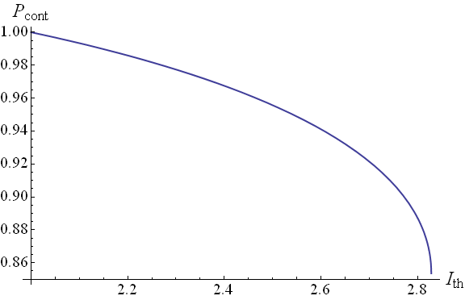

### V.2 Alice’s optimal cheating strategy in the asymptotic limit

**English original**

We present below an optimal cheating strategy, in which it suffices for Alice to perform a single two-outcome measurement, rather than a four-outcome one as described in the previous subsection. The strategy proceeds as follows. Alice prepares the boxes such that each contains one qubit out of a pair in the maximally entangled state $\left|\phi^{+}\right\rangle=\frac{1}{\sqrt{2}}\left(\left|00\right\rangle+\left|11\right\rangle\right)$ . Box $0$ is prepared such that inputting $0$ and $1$ gives rise to the measurements $\sigma_{2\theta}$ and $\sigma_{z}$ , respectively, where $\sigma_{\alpha}=\cos\alpha\sigma_{z}+\sin\alpha\sigma_{x}$ . Box $1$ is prepared such that inputting $0$ and $1$ gives rise to the measurements $\sigma_{2\theta-\varphi}$ and $\sigma_{4\theta-\varphi}$ , respectively. If Alice receives box $0$ ( $1$ ) she measures $\sigma_{3\theta-\varphi}$ ( $\sigma_{\theta}$ ). That is, she always measures along an axis midway between Bob’s measurement axes in $zx$ -plane (see Fig. 2). She then sends Bob values of $b$ and $r^{c}$ equal to the result of her measurement. Pairs of measurements along axes, differing by an angle of $\theta$ , in the $zx$ -plane (since $|\phi^{+}\rangle$ is invariant under rotations in the $zx$ -plane) give rise to correlated outcomes with probability $\cos^{2}\bigl(\frac{\theta}{2}\bigr)$ . Therefore, irrespectively of whether Alice reveals $0$ or $1$ (or, what is the same thing, whether Bob inputs $0$ or $1$ ), her cheating probability equals

**中文译文**

下面我们给出一种最优作弊策略；在该策略中，Alice 只需执行一次双结果测量，而不必执行上一小节所述的四结果测量。该策略如下。Alice 制备盒子，使每个盒子各包含一对处于最大纠缠态 $\left|\phi^{+}\right\rangle=\frac{1}{\sqrt{2}}\left(\left|00\right\rangle+\left|11\right\rangle\right)$ 的量子比特中的一个。盒子 $0$ 被制备成：输入 $0$ 和 $1$ 时分别产生测量 $\sigma_{2\theta}$ 和 $\sigma_{z}$，其中 $\sigma_{\alpha}=\cos\alpha\sigma_{z}+\sin\alpha\sigma_{x}$。盒子 $1$ 被制备成：输入 $0$ 和 $1$ 时分别产生测量 $\sigma_{2\theta-\varphi}$ 和 $\sigma_{4\theta-\varphi}$。如果 Alice 收到盒子 $0$（$1$），她就测量 $\sigma_{3\theta-\varphi}$（$\sigma_{\theta}$）。也就是说，她总是沿 $zx$ 平面中位于 Bob 两条测量轴正中间的轴进行测量（见图 2）。随后，她向 Bob 发送与其测量结果相等的 $b$ 和 $r^{c}$ 值。在 $zx$ 平面内，沿夹角为 $\theta$ 的两条轴进行的一对测量（由于 $|\phi^{+}\rangle$ 在 $zx$ 平面内的旋转下不变）以概率 $\cos^{2}\bigl(\frac{\theta}{2}\bigr)$ 产生相关结果。因此，无论 Alice 揭示 $0$ 还是 $1$（或者等价地，无论 Bob 输入 $0$ 还是 $1$），她的作弊概率均为

$$P_{\mathrm{cont}}=\cos^{2}\Bigl(\frac{\theta}{2}\Bigr)\,.
\tag{8}$$
**English original**

Of course the values of $\theta$ and $\varphi$ are restricted by the constraint on the value of the CHSH violation. For the measurements above we have

**中文译文**

当然，$\theta$ 和 $\varphi$ 的取值受到 CHSH 违反值约束的限制。对于上述测量，我们有

$$I=\langle\phi^{+}|\sigma_{2\theta}\otimes\sigma_{2\theta-\varphi}+\sigma_{2\theta}\otimes\sigma_{4\theta-\varphi}+\sigma_{z}\otimes\sigma_{2\theta-\varphi}-\sigma_{z}\otimes\sigma_{4\theta-\varphi}|\phi^{+}\rangle
=2\cos(2\theta-\varphi)-\cos(4\theta-\varphi)+\cos(\varphi)\,.
\tag{9}$$
**English original**

For a given value of $\theta$ the maximum violation is obtained for

**中文译文**

对于给定的 $\theta$ 值，最大违反在下式条件下取得：

$$\varphi_{\mathrm{opt}}=\arccos\biggl(2\frac{\cos(2\theta)+\sin^{2}(2\theta)}{\sqrt{6-2\cos(4\theta)}}\biggr)\,.
\tag{10}$$
**English original**

By plugging $\varphi_{\mathrm{opt}}$ into Eq. (9), and using Eq. (8) to obtain $\theta$ as a function of $P_{\mathrm{cont}}$ , we obtain $I$ as a function of $P_{\mathrm{cont}}$ . The resulting curve saturates the SDP obtained curve in Fig. 1.

**中文译文**

将 $\varphi_{\mathrm{opt}}$ 代入式 (9)，并利用式 (8) 将 $\theta$ 表示为 $P_{\mathrm{cont}}$ 的函数，我们便得到 $I$ 关于 $P_{\mathrm{cont}}$ 的函数。所得曲线达到图 1 中由 SDP 得到的曲线。

**English original**

Figure 2: Schematic representation of the alignment of the measurement axes in Alice’s optimal cheating strategy. The solid (dashed) axes correspond to Bob’s measurement on box $0$ ( $1$ ). The dotted axes correspond to Alice’s measurements (Alice always measures midway between Bob’s axes). The axes all lie in the $zx$ -plane. $\alpha=2\theta-\varphi_{\mathrm{opt}}$ . $\varphi_{\mathrm{opt}}$ and $\theta$ are related via Eq. (10).

**中文译文**

图 2：Alice 最优作弊策略中测量轴排列方式的示意图。实线（虚线）轴对应 Bob 在盒子 $0$（$1$）上的测量。点线轴对应 Alice 的测量（Alice 总是在 Bob 的两条轴正中间进行测量）。所有轴都位于 $zx$ 平面内。$\alpha=2\theta-\varphi_{\mathrm{opt}}$。$\varphi_{\mathrm{opt}}$ 与 $\theta$ 通过式 (10) 相关联。

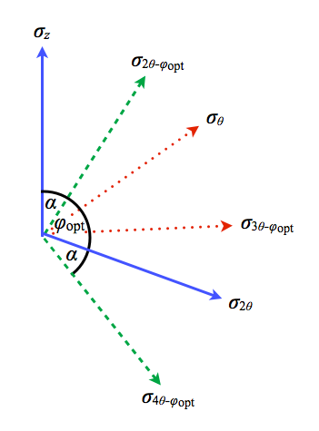

### V.3 Alice’s control in the general case of an arbitrary number of tests

**English original**

For any given value of $n$ , Alice’s control is a function of the CHSH expectation value $E(I(W_{n+1})|\mathrm{\mathbf{w}}_{n})$ characterizing the behavior of the devices at step $n+1$ given the history $\mathrm{\mathbf{w}}_{n}$ . Alice’s control can therefore be expressed as

**中文译文**

对于任意给定的 $n$ 值，Alice 的控制力是 CHSH 期望值 $E(I(W_{n+1})|\mathrm{\mathbf{w}}_{n})$ 的函数；该期望值刻画了在给定历史 $\mathrm{\mathbf{w}}_{n}$ 时设备在第 $n+1$ 步的行为。因此，Alice 的控制力可表示为

$$\begin{aligned}
P_{\mathrm{cont}}
&=
\frac{1}{N}\sum_{n=1}^{N-1}\sum_{\{\mathrm{\mathbf{w}}_{n}\}}P(\mathrm{\mathbf{w}}_{n})\Theta(\bar{I}_{n}(\mathrm{\mathbf{w}}_{n})-I_{\mathrm{th}})C\bigl(E(I(W_{n+1})\mid\mathrm{\mathbf{w}}_{n})\bigr)
\\
&\qquad
+\frac{1}{N}\sum_{\{\mathrm{\mathbf{w}}_{N}\}}P(\mathrm{\mathbf{w}}_{N})\Theta(\bar{I}_{N}(\mathrm{\mathbf{w}}_{N})-I_{\mathrm{th}})
\\
&\leq
\frac{1}{N}\sum_{n=1}^{N-1}\sum_{\{\mathrm{\mathbf{w}}_{n}\}}P(\mathrm{\mathbf{w}}_{n})\Theta(\bar{I}_{n}(\mathrm{\mathbf{w}}_{n})-I_{\mathrm{th}})C\bigl(E(I(W_{n+1})\mid\mathrm{\mathbf{w}}_{n})\bigr)+\frac{1}{N}\,.
\end{aligned}
\tag{11}$$
**English original**

where $\Theta(\bar{I}_{n}(\mathrm{\mathbf{w}}_{n})-I_{\mathrm{th}})$ is the unit step function, ensuring that only histories, such that the observed CHSH violation is no less than the threshold $I_{\mathrm{th}}$ , contribute. The partitioning of the sum into two is due to the fact that the boxes may have internal counters keeping track of the number of times they have been tested. Since the $N+1\,$ th use of the boxes, if occurring at all (i.e. if Bob picks $N$ ), necessarily occurs in the reveal phase, it is never part of the CHSH testing. Therefore, in an optimal cheating strategy Alice will program the boxes such that in their $N+1\,$ th use they behave deterministically.

**中文译文**

其中，$\Theta(\bar{I}_{n}(\mathrm{\mathbf{w}}_{n})-I_{\mathrm{th}})$ 是单位阶跃函数，它确保只有观测到的 CHSH 违反不小于阈值 $I_{\mathrm{th}}$ 的历史才有贡献。将求和拆分为两部分，是因为盒子可能带有内部计数器，用来记录它们被测试的次数。盒子的第 $N+1$ 次使用如果发生（即如果 Bob 选择 $N$），必然发生在揭示阶段，因此它从不属于 CHSH 测试的一部分。所以，在最优作弊策略中，Alice 会对盒子进行编程，使其在第 $N+1$ 次使用时表现为确定性行为。

**English original**

For each history $\mathrm{\mathbf{w}}_{n}$ with $n\leq N-2$ we can define the set of all compatible histories $\mathrm{\mathbf{w}}_{N-1}$ that could have occurred had Bob carried out $N-1$ repetitions instead of $n$ . Alice’s control can therefore be re-expressed as

**中文译文**

对于每个满足 $n\leq N-2$ 的历史 $\mathrm{\mathbf{w}}_{n}$，我们可以定义所有相容历史 $\mathrm{\mathbf{w}}_{N-1}$ 的集合；如果 Bob 执行的不是 $n$ 次而是 $N-1$ 次重复，这些历史就可能发生。因此，Alice 的控制力可重新表示为

$$P_{\mathrm{cont}}\leq\sum_{\{\mathrm{\mathbf{w}}_{N-1}\}}P(\mathrm{\mathbf{w}}_{N-1})\frac{1}{N}\sum_{n=1}^{N-1}\Theta(\bar{I}_{n}(\mathrm{\mathbf{w}}_{n})-I_{\mathrm{th}})C\bigl(E(I(W_{n+1})\mid\mathrm{\mathbf{w}}_{n})\bigr)+\frac{1}{N}\,.
\tag{12}$$
**English original**

Let $K(\mathrm{\mathbf{w}}_{N-1})$ denote the last repetition, up to and including the $N-1\,$ th repetition, of the compatible history $\mathrm{\mathbf{w}}_{N-1}$ for which the observed CHSH violation is no less than $I_{\mathrm{th}}$ , i.e.

**中文译文**

令 $K(\mathrm{\mathbf{w}}_{N-1})$ 表示在相容历史 $\mathrm{\mathbf{w}}_{N-1}$ 中，截至并包括第 $N-1$ 次重复，观测到的 CHSH 违反不小于 $I_{\mathrm{th}}$ 的最后一次重复，即

$$K(\mathrm{\mathbf{w}}_{N-1})=\max_{k\leq N-1}\{k\mid
\bar{I}_{k}(\mathrm{\mathbf{w}}_{k})\geq I_{\mathrm{th}}\}\,.
\tag{13}$$
**English original**

We can bound Alice’s control probability as follows:

**中文译文**

我们可以如下界定 Alice 的控制概率：

$$\begin{aligned}
P_{\mathrm{cont}}
&\leq
\sum_{\{\mathrm{\mathbf{w}}_{N-1}\}}P(\mathrm{\mathbf{w}}_{N-1})\frac{1}{N}\sum_{n=1}^{N-1}\Theta(\bar{I}_{n}(\mathrm{\mathbf{w}}_{n})-I_{\mathrm{th}})C\bigl(E(I(W_{n+1})\mid\mathrm{\mathbf{w}}_{n})\bigr)+\frac{1}{N}
\\
&= \sum_{k=1}^{N-1}\sum_{\{\mathrm{\mathbf{w}}_{N-1}\mid
K(\mathrm{\mathbf{w}}_{N-1})=k\}}P(\mathrm{\mathbf{w}}_{N-1})\frac{1}{N}\sum_{n=1}^{N-1}\Theta(\bar{I}_{n}(\mathrm{\mathbf{w}}_{n})-I_{\mathrm{th}})C\bigl(E(I(W_{n+1})\mid\mathrm{\mathbf{w}}_{n})\bigr)+\frac{1}{N}
\\
&\leq \sum_{k=1}^{N-1}\sum_{\{\mathrm{\mathbf{w}}_{N-1}\mid
K(\mathrm{\mathbf{w}}_{N-1})=k\}}P(\mathrm{\mathbf{w}}_{N-1})\frac{1}{N}\sum_{n=1}^{k}C\bigl(E(I(W_{n+1})\mid\mathrm{\mathbf{w}}_{n})\bigr)+\frac{1}{N}\,.
\end{aligned}
\tag{14}$$
**English original**

where we have used the fact that $\Theta(\bar{I}_{n}(\mathrm{\mathbf{w}}_{n})-I_{\mathrm{th}})=0$ for all $n$ such that $K(\mathrm{\mathbf{w}}_{N-1})<n\leq N-1$ ; the inequality being due to the possibility of histories for which $\Theta(\bar{I}_{n}(\mathrm{\mathbf{w}}_{n})-I_{\mathrm{th}})=0$ for at least one value of $n<K(\mathrm{\mathbf{w}}_{N-1})$ .

**中文译文**

这里我们使用了如下事实：对于所有满足 $K(\mathrm{\mathbf{w}}_{N-1})<n\leq N-1$ 的 $n$，都有 $\Theta(\bar{I}_{n}(\mathrm{\mathbf{w}}_{n})-I_{\mathrm{th}})=0$；之所以出现该不等式，是因为可能存在这样的历史：至少对一个满足 $n<K(\mathrm{\mathbf{w}}_{N-1})$ 的 $n$ 值，有 $\Theta(\bar{I}_{n}(\mathrm{\mathbf{w}}_{n})-I_{\mathrm{th}})=0$。

**English original**

Defining $K_{0}=\lceil(N-1)C(I_{\mathrm{th}})\rceil$ , we have

**中文译文**

定义 $K_{0}=\lceil(N-1)C(I_{\mathrm{th}})\rceil$，则有

$$\begin{aligned}
P_{\mathrm{cont}}
&\leq \sum_{k=1}^{K_{0}-1}\sum_{\{\mathrm{\mathbf{w}}_{N-1}\mid
K(\mathrm{\mathbf{w}}_{N-1})=k\}}P(\mathrm{\mathbf{w}}_{N-1})\frac{k}{N}
\\
&\qquad +\sum_{k=K_{0}}^{N-1}\sum_{\{\mathrm{\mathbf{w}}_{N-1}\mid
K(\mathrm{\mathbf{w}}_{N-1})=k\}}P(\mathrm{\mathbf{w}}_{N-1})\frac{k}{N}C\Bigl(\frac{1}{k}\sum_{n=1}^{k}E(I(W_{n+1})\mid\mathrm{\mathbf{w}}_{n})\Bigr)+\frac{1}{N}
\\
&\leq \sum_{k=1}^{K_{0}-1}\sum_{\{\mathrm{\mathbf{w}}_{N-1}\mid
K(\mathrm{\mathbf{w}}_{N-1})=k\}}P(\mathrm{\mathbf{w}}_{N-1})\frac{(N-1)C(I_{\mathrm{th}})}{N}
\\
&\qquad +\sum_{k=K_{0}}^{N-1}\sum_{\{\mathrm{\mathbf{w}}_{N-1}\mid
K(\mathrm{\mathbf{w}}_{N-1})=k,\,\mathrm{\mathbf{w}}_{N-1}\notin\pi_{k}(\varepsilon)\}}P(\mathrm{\mathbf{w}}_{N-1})\frac{N-1}{N}C\Bigl(\frac{1}{k}\sum_{n=1}^{k}E(I(W_{n+1})\mid\mathrm{\mathbf{w}}_{n})\Bigr)
\\
&\qquad +\sum_{k=K_{0}}^{N-1}\sum_{\{\mathrm{\mathbf{w}}_{N-1}\mid
K(\mathrm{\mathbf{w}}_{N-1})=k,\,\mathrm{\mathbf{w}}_{N-1}\in\pi_{k}(\varepsilon)\}}P(\mathrm{\mathbf{w}}_{N-1})\frac{N-1}{N}C\Bigl(\frac{1}{k}\sum_{n=1}^{k}E(I(W_{n+1})\mid\mathrm{\mathbf{w}}_{n})\Bigr)+\frac{1}{N}
\\
&\qquad \forall\,\varepsilon\geq 0\,.
\end{aligned}
\tag{15}$$
**English original**

where in the second sum in the first line we have used the concavity of $C$ , in the first sum in the second line the fact that $K_{0}-1\leq(N-1)C(I_{\mathrm{th}})$ , and where $\pi_{k}\left(\varepsilon\right)$ is the set of all histories satisfying

**中文译文**

其中，在第一行的第二个求和中我们使用了 $C$ 的凹性；在第二行的第一个求和中使用了 $K_{0}-1\leq(N-1)C(I_{\mathrm{th}})$ 这一事实；而 $\pi_{k}\left(\varepsilon\right)$ 是满足下式的所有历史的集合：

$$\bar{I}_{k}\left(\mathbf{w}_{k}\right)-\frac{1}{k}\sum_{n=1}^{k}E\left(I\left(W_{n}\right)\mid\mathbf{w}_{n-1}\right)\geq\varepsilon\,.
\tag{16}$$
**English original**

In Appendix D we show that the probability of occurrence of $\pi_{k}(\varepsilon)$ is bounded by

**中文译文**

在附录 D 中，我们证明 $\pi_{k}(\varepsilon)$ 的发生概率满足如下界：

$$P\left(\pi_{k}\left(\varepsilon\right)\right)\leq\exp\biggl(-\frac{k\varepsilon^{2}}{2D^{2}}\biggr)\,,
\tag{17}$$
**English original**

where $D=4+2\sqrt{2}$ , and so

**中文译文**

其中 $D=4+2\sqrt{2}$，因此

$$\sum_{k=K_{0}}^{N-1}P\left(\pi_{k}\left(\varepsilon\right)\right)\leq\frac{\exp\bigl(-\frac{K_{0}\varepsilon^{2}}{2D^{2}}\bigr)-\exp\bigl(-\frac{N\varepsilon^{2}}{2D^{2}}\bigr)}{1-\exp\left(-\frac{\varepsilon^{2}}{2D^{2}}\right)}=Q(\varepsilon)\,.
\tag{18}$$
**English original**

Figure 3: Upper bound on Alice’s control as a function of $\log_{10}N$ . The curve presents the results of numerical solutions of Eq. (19) for different values of $N$ , given $I_{\mathrm{th}}=2\sqrt{2}(1-\frac{1}{\sqrt{N}})$ . In the limit $N\rightarrow\infty$ Alice’s control tends to the asymptote $\cos^{2}\bigl(\frac{\pi}{8}\bigr)\simeq 0.854$ (represented by the dashed curve).

**中文译文**

图 3：Alice 控制力的上界随 $\log_{10}N$ 变化的关系。在给定 $I_{\mathrm{th}}=2\sqrt{2}(1-\frac{1}{\sqrt{N}})$ 时，该曲线给出了针对不同 $N$ 值对式 (19) 进行数值求解的结果。在 $N\rightarrow\infty$ 的极限下，Alice 的控制力趋于渐近线 $\cos^{2}\bigl(\frac{\pi}{8}\bigr)\simeq 0.854$（以虚线表示）。

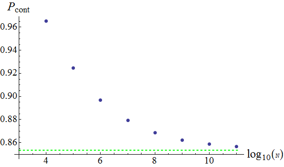

**English original**

Making use of this last inequality, we finally get that

**中文译文**

利用最后这个不等式，我们最终得到

$$\begin{aligned}
P_{\mathrm{cont}}
&\leq
\frac{N-1}{N}\sum_{k=1}^{K_{0}-1}\sum_{\{\mathrm{\mathbf{w}}_{N-1}\mid
K(\mathrm{\mathbf{w}}_{N-1})=k\}}P(\mathrm{\mathbf{w}}_{N-1})C(I_{\mathrm{th}})
\\
&\qquad +\frac{N-1}{N}\min_{\varepsilon\geq
0}\Biggl[\sum_{k=K_{0}}^{N-1}\sum_{\{\mathrm{\mathbf{w}}_{N-1}\mid
K(\mathrm{\mathbf{w}}_{N-1})=k,\,\mathrm{\mathbf{w}}_{N-1}\notin\pi_{k}(\varepsilon)\}}P(\mathrm{\mathbf{w}}_{N-1})C(\bar{I}_{k}(\mathrm{\mathbf{w}}_{k})-\varepsilon)
\\
&\qquad\qquad
+\sum_{k=K_{0}}^{N-1}\sum_{\{\mathrm{\mathbf{w}}_{N-1}\mid
K(\mathrm{\mathbf{w}}_{N-1})=k,\,\mathrm{\mathbf{w}}_{N-1}\in\pi_{k}(\varepsilon)\}}P(\mathrm{\mathbf{w}}_{N-1})\Biggr]+\frac{1}{N}
\\
&\leq \frac{N-1}{N}\min_{\varepsilon\geq
0}\Biggl[\sum_{k=1}^{K_{0}-1}\sum_{\{\mathrm{\mathbf{w}}_{N-1}\mid
K(\mathrm{\mathbf{w}}_{N-1})=k\}}P(\mathrm{\mathbf{w}}_{N-1})C(I_{\mathrm{th}}-\varepsilon)
\\
&\qquad\qquad
+\sum_{k=K_{0}}^{N-1}\sum_{\{\mathrm{\mathbf{w}}_{N-1}\mid
K(\mathrm{\mathbf{w}}_{N-1})=k\}}P(\mathrm{\mathbf{w}}_{N-1})C(I_{\mathrm{th}}-\varepsilon)
\\
&\qquad\qquad
+\sum_{k=K_{0}}^{N-1}\sum_{\{\mathrm{\mathbf{w}}_{N-1}\mid
K(\mathrm{\mathbf{w}}_{N-1})=k,\,\mathrm{\mathbf{w}}_{N-1}\in\pi_{k}(\varepsilon)\}}P(\mathrm{\mathbf{w}}_{N-1})\bigl(1-C(I_{\mathrm{th}}-\varepsilon)\bigr)\Biggr]+\frac{1}{N}
\\
&\leq \frac{N-1}{N}\min_{\varepsilon\geq
0}\Bigl[C(I_{\mathrm{th}}-\varepsilon)+\bigl(1-C(I_{\mathrm{th}}-\varepsilon)\bigr)Q(\varepsilon)\Bigr]+\frac{1}{N}\,.
\end{aligned}
\tag{19}$$
**English original**

Note that if we choose the behavior of $\varepsilon$ such that in the limit $N\rightarrow\infty$ it decays more slowly than $N^{-1/2}$ , then $\lim_{N\rightarrow\infty}Q(\varepsilon)\rightarrow 0$ and the bound tends to $C(I_{\mathrm{th}})$ . For finite $N$ it seems unlikely that the bound is saturable, since $Q(\varepsilon)$ is non-vanishing. Fig. 3 presents the results of numerical solutions of Eq. (19) for different values of $N$ for $I_{\mathrm{th}}=2\sqrt{2}-\frac{1}{\sqrt{N}}$ . In particular, in the limit $N\rightarrow\infty$ Alice’s control tends to $\cos^{2}\left(\frac{\pi}{8}\right)$ , recovering the result of [30].

**中文译文**

注意，如果我们选择 $\varepsilon$ 的变化方式，使其在 $N\rightarrow\infty$ 的极限下比 $N^{-1/2}$ 衰减得更慢，那么 $\lim_{N\rightarrow\infty}Q(\varepsilon)\rightarrow 0$，且该界趋于 $C(I_{\mathrm{th}})$。对于有限的 $N$，由于 $Q(\varepsilon)$ 非零，该界似乎不太可能达到。图 3 给出了在 $I_{\mathrm{th}}=2\sqrt{2}-\frac{1}{\sqrt{N}}$ 时，针对不同 $N$ 值对式 (19) 进行数值求解的结果。特别地，在 $N\rightarrow\infty$ 的极限下，Alice 的控制力趋于 $\cos^{2}\left(\frac{\pi}{8}\right)$，从而重新得到 [30] 的结果。

## VI Summary

**English original**

Distrustful cryptography presents unique challenges in device-independent settings, which are absent in non-distrustful cryptographic tasks, such as quantum key-distribution. In particular, since the parties do not trust each other and may have conflicting goals, they cannot work together to certify the presence of nonlocality. In [30, 35] this problem was circumvented by making use of the pseudo-telepathic nature of GHZ correlations, but pseudo-telepathy is absent in a CHSH setting. In this work we have shown that pseudo-telepathy is not essential for doing device-independent distrustful cryptography. This was achieved by reformulating the device-independent bit commitment protocol of [30], such that it relies on sequential testing of the CHSH inequality (instead of the single-shot testing of GHZ correlations), but (in the asymptotic limit) nevertheless achieves the same security. The security analysis was therefore carried out in the most general settings, where the devices may have long-term quantum memory.

**中文译文**

不互信密码学在设备无关情形下面临独特的挑战，而这些挑战并不存在于量子密钥分发等非不互信密码任务中。特别是，由于双方互不信任且目标可能相互冲突，他们无法合作认证非局域性的存在。在 [30, 35] 中，这一问题通过利用 GHZ 关联的伪心灵感应性质得以规避，但在 CHSH 情形中不存在伪心灵感应。在本工作中，我们证明了开展设备无关不互信密码学并不必须依赖伪心灵感应。我们通过重新表述 [30] 的设备无关比特承诺协议实现了这一点：使其依赖对 CHSH 不等式的序贯测试（而非对 GHZ 关联的单次测试），但在渐近极限下仍能达到相同的安全性。因此，安全性分析是在最一般的情形下进行的，其中设备可能具有长期量子存储器。

**English original**

Strictly speaking, the protocol we have presented is not a bit commitment protocol since Alice cannot choose the reveal time at will. This by itself is not necessarily a problem. For example, it does not prevent the protocol from being used to implement coin flipping. However, if we would like Alice to have the freedom to choose the reveal time, then we can do so either, as shown in Appendix B, at the price of increasing her control, or, as shown in Appendix C, at the price of using additional resources, i.e. by working in the large office scenario, where the parties have access to many pairs of boxes, which can be measured in parallel.

**中文译文**

严格来说，我们给出的协议并不是一个比特承诺协议，因为 Alice 不能随意选择揭示时间。这一点本身未必构成问题。例如，它并不妨碍该协议被用于实现抛硬币。然而，如果我们希望 Alice 可以自由选择揭示时间，那么可以采用两种方式做到这一点：或者如附录 B 所示，以增加她的控制力为代价；或者如附录 C 所示，以使用额外资源为代价，即在大型办公室情形下工作，其中双方可以使用许多对能够并行测量的盒子。

**English original**

Our work opens the door for real-life implementation of device-independent bit commitment and coin flipping. The protocol of [30] requires the ability to reliably produce particles in a GHZ state and to store, manipulate, and transmit them while maintaining their coherence. The protocol presented here, on the other hand, only requires manipulation of bipartite entanglement which is simpler given state-of-the-art technology.

**中文译文**

我们的工作为设备无关比特承诺和抛硬币的实际实现打开了大门。[30] 的协议要求能够可靠地产生处于 GHZ 态的粒子，并在保持其相干性的同时对其进行存储、操纵和传输。相比之下，本文给出的协议只需操纵二体纠缠；以当前最先进的技术而言，这更为简单。

**English original**

Finally, we point out that the techniques developed in this work are not especially tailored for device-independent bit commitment, and we expect them to be useful, and possibly even essential, for other distrustful cryptographic tasks, such as non-bit commitment-based device-independent coin flipping, and device-independent oblivious transfer.

**中文译文**

最后，我们指出，本工作所发展的技术并非专门针对设备无关比特承诺而定制；我们预计，这些技术对于其他不互信密码任务也会有用，甚至可能不可或缺，例如不基于比特承诺的设备无关抛硬币，以及设备无关不经意传输。

###### Acknowledgements.

**English original**

S.P., S.M., and J.S. acknowledge financial support from the European Union under the projects QCS, QALGO, and DIQIP, and from the F.R.S.-FNRS under the project DIQIP. S.P. acknowledges support from the Brussels-Capital Region through a BB2B grant. S.P. is a Research Associate of the Fonds de la Recherche Scientifique F.R.S.- FNRS (Belgium). J.S. was a postdoctoral researcher of the Fonds de la Recherche Scientifique F.R.S.- FNRS (Belgium) at the time this research was carried out. N.A acknowledges support from the BSF (grant no. 32/08) and the Niedersachsen-Israeli Research Cooperation Program. The Matlab toolboxes YALMIP [44] and SeDuMi [45] were used to solve the SDP problem Eq. (7).

**中文译文**

S.P.、S.M. 和 J.S. 感谢欧盟通过 QCS、QALGO 和 DIQIP 项目提供的资助，以及 F.R.S.-FNRS 通过 DIQIP 项目提供的资助。S.P. 感谢布鲁塞尔首都大区通过一项 BB2B 资助提供的支持。S.P. 是科学研究基金会 F.R.S.-FNRS（比利时）的研究员。开展本项研究时，J.S. 是科学研究基金会 F.R.S.-FNRS（比利时）的博士后研究员。N.A 感谢 BSF（资助编号 32/08）和下萨克森—以色列研究合作计划的支持。求解式 (7) 的 SDP 问题时使用了 Matlab 工具箱 YALMIP [44] 和 SeDuMi [45]。

# Appendices and References / 附录与参考文献

## Appendix A / 附录 A

**English original**

We present a device-independent bit commitment protocol using a PR box [46].

**中文译文**

我们提出一种使用 PR 盒 [46] 的设备无关比特承诺协议。

**English original**

We have seen that reformulating the GHZ-based protocol of [30] to be CHSH-based comes at the price of pseudo-telepathy. Indeed, quantum theory does not allow for pseudo-telepathy in a two-party, two-input setting [39]. However, in a post-quantum world – in which both dishonest and honest parties are restricted only by the no-signaling constraints – pseudo-telepathy is restored. It is interesting to ask what would happen to our protocol if we were to adapt it to such a world. On the one hand, we might expect such a world to offer less security since a dishonest party would now have access to stronger correlations. On the other hand, we might expect the converse, since the protocol itself can be modified to make use of these stronger correlations. We will see that on the balance this allows for more security.[^7]

**中文译文**

我们已经看到，将 [30] 中基于 GHZ 的协议改写为基于 CHSH 的协议，是以失去伪心灵感应为代价的。事实上，量子理论不允许在双方、双输入的场景中出现伪心灵感应 [39]。然而，在一个后量子世界中——无论不诚实方还是诚实方都只受无信号约束限制——伪心灵感应得以恢复。值得探究的是，如果我们调整协议以适应这样的世界，会发生什么。一方面，我们或许预期这样的世界安全性较低，因为不诚实方现在可以利用更强的关联。另一方面，我们也可能预期相反的结果，因为协议本身可以修改以利用这些更强的关联。我们将看到，总体而言，这会带来更高的安全性。[^8]

**English original**

A PR box is a post-quantum, bipartite, two-input, two-output resource, which achieves the algebraic bound of the CHSH inequality, while at the same time satisfying the no-signaling constraints. Up to local relabeling of the inputs and outputs, the PR box satisfies

**中文译文**

PR 盒是一种后量子的、二分的、双输入双输出资源；它在达到 CHSH 不等式代数界的同时满足无信号约束。在不计输入和输出的局部重新标记时，PR 盒满足

**English original**

$$r^{0}\oplus r^{1}=s^{0}\cdot s^{1}\,,\qquad r^{i},\,s^{i}\in\{0,\,1\}\,.
\tag{20}$$

**中文译文**

$$r^{0}\oplus r^{1}=s^{0}\cdot s^{1}\,,\qquad r^{i},\,s^{i}\in\{0,\,1\}\,.
\tag{20}$$

**English original**

In the following, it will be convenient to think of the PR box as consisting of a pair of two-input, two-output boxes, one in the possession of Alice, and the other in the possession of Bob.

**中文译文**

下文中，为方便起见，可将 PR 盒视为由一对双输入双输出盒组成，其中一个由 Alice 持有，另一个由 Bob 持有。

**English original**

The PR-based protocol is essentially a simplified version of our earlier protocols with the first step (statistical estimation of the CHSH violation and random selection of the box used to encode Alice’s commitment) omitted, and with the verification of nonlocal correlations and Alice’s commitment being performed at the same time. This last possibility follows from pseudo-telepathy, as in the protocol of [30].

**中文译文**

基于 PR 的协议本质上是我们先前协议的简化版本：省略了第一步（对 CHSH 违反进行统计估计，以及随机选择用于编码 Alice 承诺的盒），并同时执行非局域关联验证与 Alice 的承诺。后一种做法源于伪心灵感应，正如 [30] 的协议一样。

**English original**

We assume that at the start of the protocol Alice has box $0$ and Bob has box $1$ . The protocol proceeds as follows:

**中文译文**

我们假设在协议开始时，Alice 持有盒 $0$，Bob 持有盒 $1$。协议步骤如下：

**English original**

1. Commit phase - Alice inputs into her box the value of the bit she wishes to commit. She then selects uniformly at random a classical bit $a$ , and sends Bob another classical bit, $q=r^{0}\oplus(as^{0})$ , as a token of her commitment.

**中文译文**

1. 承诺阶段——Alice 将她希望承诺的比特值输入自己的盒。随后，她均匀随机地选择一个经典比特 $a$，并向 Bob 发送另一个经典比特 $q=r^{0}\oplus(as^{0})$，作为其承诺的凭证。

**English original**

2. Reveal phase - Alice sends Bob $s^{0}$ and $r^{0}$ . Bob checks whether $q=r^{0}$ or $q=r^{0}\oplus s^{0}$ . If both relations are not satisfied, he aborts. Otherwise, he picks an input $s^{1}$ uniformly at random and verifies that $r^{0}\oplus r^{1}=s^{0}\cdot s^{1}$ . If this last test fails, he aborts.

**中文译文**

2. 揭示阶段——Alice 向 Bob 发送 $s^{0}$ 和 $r^{0}$。Bob 检查 $q=r^{0}$ 或 $q=r^{0}\oplus s^{0}$ 是否成立。如果两个关系均不成立，他就中止协议。否则，他均匀随机地选择一个输入 $s^{1}$，并验证 $r^{0}\oplus r^{1}=s^{0}\cdot s^{1}$。如果最后这项检验失败，他就中止协议。

### Alice’s security / Alice 的安全性

**English original**

We recall that in the quantum case (both in the GHZ-based and CHSH-based formulations) Alice’s security relies only on the no-signaling constraints. Since we are still working in a non-signaling setting, Alice’s security will remain unchanged, i.e. Bob’s information gain is upper-bounded by $\frac{3}{4}$ . The proof proceeds exactly as in Subsection IV.A, except that the instead of inputting $2$ and $3$ , Alice inputs $0$ and $1$ .

**中文译文**

回顾量子情形（无论基于 GHZ 还是基于 CHSH 的表述），Alice 的安全性仅依赖于无信号约束。由于我们仍在无信号场景中讨论，Alice 的安全性保持不变，即 Bob 的信息增益上界为 $\frac{3}{4}$。证明与第 IV.A 小节完全相同，唯一的区别是 Alice 输入 $0$ 和 $1$，而不是输入 $2$ 和 $3$。

**English original**

One optimal strategy for Bob is to assume that $q=r^{0}$ , and input $s^{1}=1$ , obtaining an output $r^{1}$ . He then guesses $g=r^{0}\oplus r^{1}$ . When $s^{0}=0$ , $q=r^{0}$ and Bob’s guess, $g=r^{0}\oplus r^{1}=s^{0}$ , is correct. When $s^{0}=1$ and $a=0$ , $q=r^{0}$ and Bob’s guess, $g=r^{0}\oplus r^{1}=s^{0}$ , is again correct. However, when $s^{0}=1$ and $a=1$ , $q=r^{0}\oplus 1$ and Bob’s guess, $g=r^{0}\oplus r^{1}\oplus 1=s^{0}\oplus 1$ , is wrong. Since Alice is honest she picks $a$ uniformly at random, implying that $P_{\mathrm{gain}}=\frac{3}{4}$ .

**中文译文**

Bob 的一种最优策略是假设 $q=r^{0}$，并输入 $s^{1}=1$，得到输出 $r^{1}$。然后他猜测 $g=r^{0}\oplus r^{1}$。当 $s^{0}=0$ 时，$q=r^{0}$，且 Bob 的猜测 $g=r^{0}\oplus r^{1}=s^{0}$ 正确。当 $s^{0}=1$ 且 $a=0$ 时，$q=r^{0}$，Bob 的猜测 $g=r^{0}\oplus r^{1}=s^{0}$ 仍然正确。然而，当 $s^{0}=1$ 且 $a=1$ 时，$q=r^{0}\oplus 1$，Bob 的猜测 $g=r^{0}\oplus r^{1}\oplus 1=s^{0}\oplus 1$ 是错误的。由于 Alice 是诚实的，她均匀随机地选择 $a$，这意味着 $P_{\mathrm{gain}}=\frac{3}{4}$。

### Bob’s security / Bob 的安全性

**English original**

Recall that in a device-independent scenario dishonest Alice can prepare the boxes in any state she wishes, possibly entangled with ancillary systems in her possession. Since in the commit phase Alice sends a classical bit $q$ as a token of her commitment, without receiving any information from Bob, without loss of generality we may assume that she decides on the value of $q$ before the start of the protocol, and accordingly prepares the boxes to maximize $P_{\mathrm{cont}}$ . Furthermore, since Alice’s cheating probability is invariant under the simultaneous relabeling $q\rightarrow q\oplus 1$ and $r^{0}\rightarrow r^{0}\oplus 1$ , no value of $q$ is preferable, and we may assume that she sends $q=0$ .

**中文译文**

回顾设备无关场景，不诚实的 Alice 可以按自己的意愿将盒制备为任意状态，这些盒还可能与她持有的辅助系统纠缠。由于在承诺阶段，Alice 在未从 Bob 接收任何信息的情况下发送经典比特 $q$ 作为承诺凭证，因此不失一般性，可以假设她在协议开始前就决定 $q$ 的值，并据此制备盒以最大化 $P_{\mathrm{cont}}$。此外，由于 Alice 的作弊概率在同时重新标记 $q\rightarrow q\oplus 1$ 和 $r^{0}\rightarrow r^{0}\oplus 1$ 下不变，因此没有哪个 $q$ 值更有利，我们可以假设她发送 $q=0$。

**English original**

Suppose now that Alice wishes to reveal $0$ . Since $s^{0}=0$ , it follows that Alice must send $r^{0}=0$ as Bob will first check whether $r^{0}=0$ or not. Bob will then test whether the PR box correlations, Eq. (20), are satisfied: Bob will uniformly at random pick a value of $s^{1}$ and verify that $r^{1}=0$ . Alice’s control in this case equals $\frac{1}{2}\left[P\left(r^{1}=0|s^{1}=0\right)+P\left(r^{1}=0|s^{1}=1\right)\right]$ . Suppose now that Alice wishes to reveal $1$ , then both values of $r^{1}$ are possible, and the only relevant test is whether the PR box correlations are satisfied. Alice’s control in this case equals $\frac{1}{2}\sum_{r^{0}=0,\,1}\left[P\left(r^{0},\,r^{1}=r^{0}|s^{0}=1,\,s^{1}=0\right)+P\left(r^{0},\,r^{1}=r^{0}\oplus 1|s^{0}=1,\,s^{1}=1\right)\right]$ . Alice’s overall control is obtained by maximizing

**中文译文**

现在假设 Alice 希望揭示 $0$。由于 $s^{0}=0$，Alice 必须发送 $r^{0}=0$，因为 Bob 首先会检查 $r^{0}=0$ 是否成立。随后，Bob 将检验 PR 盒关联式 (20) 是否成立：Bob 均匀随机地选取一个 $s^{1}$ 值，并验证 $r^{1}=0$。在这种情况下，Alice 的控制力等于 $\frac{1}{2}\left[P\left(r^{1}=0|s^{1}=0\right)+P\left(r^{1}=0|s^{1}=1\right)\right]$。现在假设 Alice 希望揭示 $1$，那么 $r^{1}$ 的两个值都可能出现，唯一相关的检验是 PR 盒关联是否成立。在这种情况下，Alice 的控制力等于 $\frac{1}{2}\sum_{r^{0}=0,\,1}\left[P\left(r^{0},\,r^{1}=r^{0}|s^{0}=1,\,s^{1}=0\right)+P\left(r^{0},\,r^{1}=r^{0}\oplus 1|s^{0}=1,\,s^{1}=1\right)\right]$。Alice 的总体控制力通过最大化下式得到：

**English original**

$$\begin{aligned}
&\frac{1}{4}\left[P(r^{1}=0|s^{1}=0)+P(r^{1}=0|s^{1}=1)\right.\\
&\quad+\sum_{r^{0}=0,\,1}\bigl(P(r^{0},\,r^{1}=r^{0}\mid
s^{0}=1,\,s^{1}=0)+\left.P(r^{0},\,r^{1}=r^{0}\oplus 1\mid
s^{0}=1,\,s^{1}=1)\bigl)\right]\\
&=\frac{1}{4}\left[P(r^{1}=0|s^{1}=0)+P(r^{1}=0|s^{1}=1)\right.\\
&\quad+P(r^{0}=0,\,r^{1}=0\mid
s^{0}=1,\,s^{1}=0)+P(r^{0}=0,\,r^{1}=1\mid s^{0}=1,\,s^{1}=1)\\
&\quad+P(r^{0}=1,\,r^{1}=1\mid
s^{0}=1,\,s^{1}=0)+\left.P(r^{0}=1,\,r^{1}=0\mid
s^{0}=1,\,s^{1}=1)\right]
\end{aligned}
\tag{21}$$

**中文译文**

$$\begin{aligned}
&\frac{1}{4}\left[P(r^{1}=0|s^{1}=0)+P(r^{1}=0|s^{1}=1)\right.\\
&\quad+\sum_{r^{0}=0,\,1}\bigl(P(r^{0},\,r^{1}=r^{0}\mid
s^{0}=1,\,s^{1}=0)+\left.P(r^{0},\,r^{1}=r^{0}\oplus 1\mid
s^{0}=1,\,s^{1}=1)\bigl)\right]\\
&=\frac{1}{4}\left[P(r^{1}=0|s^{1}=0)+P(r^{1}=0|s^{1}=1)\right.\\
&\quad+P(r^{0}=0,\,r^{1}=0\mid
s^{0}=1,\,s^{1}=0)+P(r^{0}=0,\,r^{1}=1\mid s^{0}=1,\,s^{1}=1)\\
&\quad+P(r^{0}=1,\,r^{1}=1\mid
s^{0}=1,\,s^{1}=0)+\left.P(r^{0}=1,\,r^{1}=0\mid
s^{0}=1,\,s^{1}=1)\right]
\end{aligned}
\tag{21}$$

**English original**

and is easily seen to be no greater than $\frac{3}{4}$ .

**中文译文**

并且很容易看出，其值不超过 $\frac{3}{4}$。

**English original**

Alice’s optimal strategy is to prepare Bob’s box such that $P(r^{1}=0|s^{1}=0)=P(r^{1}=0|s^{1}=1)=1$ , i.e. a classical box.

**中文译文**

Alice 的最优策略是将 Bob 的盒制备为满足 $P(r^{1}=0|s^{1}=0)=P(r^{1}=0|s^{1}=1)=1$ 的盒，即一个经典盒。

## Appendix B / 附录 B

**English original**

In this appendix we consider a modification of the protocol, such that the reveal time can be chosen at will. This comes at the price of increasing Alice’s control. The protocol proceeds as follows:

**中文译文**

本附录考虑对协议的一种修改，使揭示时间可以任意选择。其代价是增大 Alice 的控制力。协议步骤如下：

**English original**

1. Random selection – At time $t^{a}<t_{1}$ Bob picks uniformly at random, and in private, a number $n\in\{1,\,\dots,\,N\}$ and two input strings $\mathrm{\mathbf{s}}^{0}_{n}\in\{0,\,1\}^{n}$ and $\mathrm{\mathbf{s}}^{1}_{n}\in\{0,\,1\}^{n}$ . At each of the $n$ times $t_{i}$ he feeds $s^{0}_{i}$ and $s^{1}_{i}$ into boxes $0$ and $1$ , respectively. He uses the corresponding output strings $\mathrm{\mathbf{r}}^{0}_{n}$ and $\mathrm{\mathbf{r}}^{1}_{n}$ to compute the observed CHSH violation, $\bar{I}_{n}(\mathrm{\mathbf{w}}_{n})$ , and compares it to some previously agreed threshold $I_{\mathrm{th}}$ . If $\bar{I}_{n}(\mathrm{\mathbf{w}}_{n})<I_{\mathrm{th}}$ , he aborts the protocol. Otherwise, he flips two classical coins. Denote their outcomes by $c$ and $d$ . At time $t^{b}<t_{n+1}$ he sends box $c$ to Alice. At time $t_{n+1}$ , he inputs $s_{n+1}^{\bar{c}}=d$ into box $\bar{c}$ .

**中文译文**

1. 随机选择——在时刻 $t^{a}<t_{1}$，Bob 私下均匀随机地选取一个数 $n\in\{1,\,\dots,\,N\}$ 和两个输入串 $\mathrm{\mathbf{s}}^{0}_{n}\in\{0,\,1\}^{n}$、$\mathrm{\mathbf{s}}^{1}_{n}\in\{0,\,1\}^{n}$。在 $n$ 个时刻 $t_i$ 中的每一个时刻，他分别将 $s^{0}_{i}$ 和 $s^{1}_{i}$ 输入盒 $0$ 和盒 $1$。他使用相应的输出串 $\mathrm{\mathbf{r}}^{0}_{n}$ 和 $\mathrm{\mathbf{r}}^{1}_{n}$ 计算观测到的 CHSH 违反 $\bar{I}_{n}(\mathrm{\mathbf{w}}_{n})$，并将其与事先约定的阈值 $I_{\mathrm{th}}$ 比较。如果 $\bar{I}_{n}(\mathrm{\mathbf{w}}_{n})<I_{\mathrm{th}}$，他就中止协议。否则，他抛掷两枚经典硬币，将结果记为 $c$ 和 $d$。在时刻 $t^{b}<t_{n+1}$，他将盒 $c$ 发送给 Alice。在时刻 $t_{n+1}$，他把 $s_{n+1}^{\bar{c}}=d$ 输入盒 $\bar{c}$。

**English original**

2. Commit phase – Let $b$ be the value of the bit Alice wishes to commit. Alice inputs $s^{c}_{n+1}=b+2$ into her box. She then selects uniformly at random a classical bit $a$ , and at time $t^{c}>t^{b}$ sends Bob the classical bit $q=r^{c}_{n+1}\oplus ab$ as a token of her commitment.

**中文译文**

2. 承诺阶段——令 $b$ 为 Alice 希望承诺的比特值。Alice 将 $s^{c}_{n+1}=b+2$ 输入她的盒。随后，她均匀随机地选择一个经典比特 $a$，并在时刻 $t^{c}>t^{b}$ 向 Bob 发送经典比特 $q=r^{c}_{n+1}\oplus ab$，作为其承诺的凭证。

**English original**

3. Reveal phase – At any time of her choosing $t>t^{c}$ Alice sends Bob $b$ and $r^{c}_{n+1}$ . Bob checks whether $q=r^{c}_{n+1}$ or $q=r^{c}_{n+1}\oplus b$ . If both relations are not satisfied, he aborts. Otherwise, if $s^{\bar{c}}_{n+1}=s^{c}_{n+1}-2$ (i.e. $d=b-2$ ) he verifies that $r^{\bar{c}}_{n+1}=r^{c}_{n+1}$ . If this last test fails, he aborts.

**中文译文**

3. 揭示阶段——在 Alice 选择的任意时刻 $t>t^{c}$，她向 Bob 发送 $b$ 和 $r^{c}_{n+1}$。Bob 检查 $q=r^{c}_{n+1}$ 或 $q=r^{c}_{n+1}\oplus b$ 是否成立。如果两个关系均不成立，他就中止协议。否则，如果 $s^{\bar{c}}_{n+1}=s^{c}_{n+1}-2$（即 $d=b-2$），他就验证 $r^{\bar{c}}_{n+1}=r^{c}_{n+1}$。如果最后这项检验失败，他就中止协议。

### Alice’s security / Alice 的安全性

**English original**

Clearly, the analysis of Alice’s security remains the same as in the original protocol.

**中文译文**

显然，对 Alice 安全性的分析与原协议相同。

### Bob’s security / Bob 的安全性

**English original**

Bob’s random choice of the $n+1\,$ th input into box $\bar{c}$ implies that half the time he will not be able to carry out the last test in the reveal phase and will accept whatever value dishonest Alice reveals, independently of her cheating strategy. The remaining half of the time, Bob’s actions will precisely be identical to those analyzed previously (in particular, the last input is introduced into box $\bar{c}$ at time $t_{n+1}$ , and thus, unless $n=N$ , this box cannot tell whether it is measured in the random selection phase or the reveal phase). Alice’s control is therefore modified as follows: $P_{\mathrm{cont}}\rightarrow\frac{1}{2}(P_{\mathrm{cont}}+1)$ .

**中文译文**

Bob 随机选择盒 $\bar{c}$ 的第 $n+1$ 个输入，这意味着有一半时间他无法执行揭示阶段的最后一项检验，并且无论不诚实的 Alice 采用何种作弊策略，他都会接受她揭示的任何值。在其余一半时间里，Bob 的操作与先前分析的操作完全相同（特别是，最后一个输入在时刻 $t_{n+1}$ 被送入盒 $\bar{c}$；因此，除非 $n=N$，该盒无法判断自己是在随机选择阶段还是揭示阶段被测量）。因此，Alice 的控制力修改为：$P_{\mathrm{cont}}\rightarrow\frac{1}{2}(P_{\mathrm{cont}}+1)$。

## Appendix C / 附录 C

**English original**

In this appendix we consider the large office scenario, where Bob has a large number of pairs of boxes, and where the boxes in each pair can not only be prevented from communicating with one another, but also with the other pairs. While impractical, this scenario allows us to modify the protocol such that the reveal time can be chosen at will while maintaining the same level of security.

**中文译文**

本附录考虑“大办公室”场景，其中 Bob 拥有大量盒对，并且不仅能阻止每一对中的盒相互通信，也能阻止它们与其他盒对通信。尽管不切实际，这一场景使我们能够修改协议，使揭示时间可以任意选择，同时维持相同的安全水平。

**English original**

Before we begin, we adapt the notation to this new scenario. We consider $N+1$ pairs[^9] of four-input, $\{0,\,1,\,2,\,3\}$ , two-output, $\{0,\,1\}$ , boxes. The random variables designating the input and output of the $i\,$ th box ( $i\in\{0,\,1\}$ ) of the $k\,$ th pair will be labeled by $S^{i}_{k}$ and $R^{i}_{k}$ , respectively, with a specific realization being labeled by lower-case letters $s^{i}_{k}$ and $r^{i}_{k}$ . We also define $W_{k}=\{S^{0}_{k},\,S^{1}_{k},\,R^{0}_{k},\,R^{1}_{k}\}$ and $\mathbf{W}_{n}=\{W_{1},\,\dots,\,W_{n}\}$ . Finally, we define the random strings $\mathbf{S}^{i}_{\bar{n}}=\{S^{i}_{1},\,\dots,\,S^{i}_{n-1},\,S^{i}_{n+1},\,\dots,\,S^{i}_{N+1}\}$ , $\mathbf{R}^{i}_{\bar{n}}=\{R^{i}_{1},\,\dots,\,R^{i}_{n-1},\,R^{i}_{n+1},\,\dots,\,R^{i}_{N+1}\}$ , and $\mathbf{W}_{\bar{n}}=\{W_{1},\,\dots,\,W_{n-1},\,W_{n+1},\,\dots,\,W_{N+1}\}$ .

**中文译文**

开始之前，我们先使记号适应这一新场景。考虑 $N+1$ 对[^10]四输入 $\{0,\,1,\,2,\,3\}$、双输出 $\{0,\,1\}$ 的盒。表示第 $k$ 对中第 $i$ 个盒（$i\in\{0,\,1\}$）的输入和输出的随机变量，分别记为 $S^{i}_{k}$ 和 $R^{i}_{k}$；其具体实现值以小写字母 $s^{i}_{k}$ 和 $r^{i}_{k}$ 表示。我们还定义 $W_{k}=\{S^{0}_{k},\,S^{1}_{k},\,R^{0}_{k},\,R^{1}_{k}\}$ 和 $\mathbf{W}_{n}=\{W_{1},\,\dots,\,W_{n}\}$。最后，定义随机串 $\mathbf{S}^{i}_{\bar{n}}=\{S^{i}_{1},\,\dots,\,S^{i}_{n-1},\,S^{i}_{n+1},\,\dots,\,S^{i}_{N+1}\}$、$\mathbf{R}^{i}_{\bar{n}}=\{R^{i}_{1},\,\dots,\,R^{i}_{n-1},\,R^{i}_{n+1},\,\dots,\,R^{i}_{N+1}\}$ 以及 $\mathbf{W}_{\bar{n}}=\{W_{1},\,\dots,\,W_{n-1},\,W_{n+1},\,\dots,\,W_{N+1}\}$。

**English original**

The protocol proceeds as follows:

**中文译文**

协议步骤如下：

**English original**

1. Random selection – Bob picks uniformly at random and in private a number $n\in\{1,\,\dots,\,N+1\}$ and a classical bit $c$ . He sends box $c$ of the $n\,$ th pair to Alice.

**中文译文**

1. 随机选择——Bob 私下均匀随机地选取一个数 $n\in\{1,\,\dots,\,N+1\}$ 和一个经典比特 $c$。他将第 $n$ 对中的盒 $c$ 发送给 Alice。

**English original**

2. Commit phase – Let $b$ be the value of the bit Alice wishes to commit. Alice inputs $s^{c}_{n}=b+2$ into her box. She then selects uniformly at random a classical bit $a$ , and sends Bob the classical bit $q=r^{c}_{n+1}\oplus ab$ as a token of her commitment.

**中文译文**

2. 承诺阶段——令 $b$ 为 Alice 希望承诺的比特值。Alice 将 $s^{c}_{n}=b+2$ 输入她的盒。随后，她均匀随机地选择一个经典比特 $a$，并向 Bob 发送经典比特 $q=r^{c}_{n+1}\oplus ab$，作为其承诺的凭证。

**English original**

3. Reveal phase – Alice sends Bob $b$ and $r^{c}_{n}$ . Bob checks whether $q=r^{c}_{n}$ or $q=r^{c}_{n}\oplus b$ . If both relations are not satisfied, he aborts. Otherwise, he picks uniformly at random two input strings $\mathrm{\mathbf{s}}^{0}_{\bar{n}}\in\{0,\,1\}^{N}$ and $\mathrm{\mathbf{s}}^{1}_{\bar{n}}\in\{0,\,1\}^{N}$ , which he feeds into the corresponding boxes. At the same time he feeds $s^{\bar{c}}_{n}=s^{c}_{n}-2=b$ into box $\bar{c}$ of the $n\,$ th pair. If $r^{\bar{c}}_{n+1}\neq r^{c}_{n+1}$ , he aborts. Else, he uses the corresponding output strings $\mathrm{\mathbf{r}}^{0}_{\bar{n}}$ and $\mathrm{\mathbf{r}}^{1}_{\bar{n}}$ to compute the observed CHSH violation $\bar{I}_{\bar{n}}(\mathbf{w}_{\bar{n}})=\frac{1}{N}\sum_{k\neq n}I(w_{k})$ and compares it to some previously agreed threshold $I_{\mathrm{th}}$ . If this last test fails, he aborts.

**中文译文**

3. 揭示阶段——Alice 向 Bob 发送 $b$ 和 $r^{c}_{n}$。Bob 检查 $q=r^{c}_{n}$ 或 $q=r^{c}_{n}\oplus b$ 是否成立。如果两个关系均不成立，他就中止协议。否则，他均匀随机地选择两个输入串 $\mathrm{\mathbf{s}}^{0}_{\bar{n}}\in\{0,\,1\}^{N}$ 和 $\mathrm{\mathbf{s}}^{1}_{\bar{n}}\in\{0,\,1\}^{N}$，并将其送入相应的盒。同时，他将 $s^{\bar{c}}_{n}=s^{c}_{n}-2=b$ 输入第 $n$ 对的盒 $\bar{c}$。如果 $r^{\bar{c}}_{n+1}\neq r^{c}_{n+1}$，他就中止协议。否则，他使用相应的输出串 $\mathrm{\mathbf{r}}^{0}_{\bar{n}}$ 和 $\mathrm{\mathbf{r}}^{1}_{\bar{n}}$ 计算观测到的 CHSH 违反 $\bar{I}_{\bar{n}}(\mathbf{w}_{\bar{n}})=\frac{1}{N}\sum_{k\neq n}I(w_{k})$，并将其与事先约定的阈值 $I_{\mathrm{th}}$ 比较。如果最后这项检验失败，他就中止协议。

### Alice’s security / Alice 的安全性

**English original**

Clearly, the analysis of Alice’s security remains the same as in the original protocol.

**中文译文**

显然，对 Alice 安全性的分析与原协议相同。

### Bob’s security / Bob 的安全性

**English original**

We will not derive here the dependence of Alice’s control on the number of pairs $N+1$ . Instead, we will show that it is upper-bounded by that of the original protocol (Section III). To see this, consider another protocol, identical to the one above in all except that instead of using the inputs and outputs of all the pairs (bar the one chosen for the commitment) to estimate the CHSH violation, Bob uses only those of the first $n-1$ pairs (Alice is of course aware of this and of the numbering of the pairs). Clearly, the new protocol can only increase Alice’s control.

**中文译文**

这里我们不推导 Alice 的控制力对盒对数 $N+1$ 的依赖关系。相反，我们将证明它的上界为原协议（第 III 节）中的控制力。为说明这一点，考虑另一个协议：除了 Bob 不使用所有盒对（用于承诺的那一对除外）的输入和输出来估计 CHSH 违反，而只使用前 $n-1$ 对的输入和输出以外，该协议与上述协议完全相同（Alice 当然知道这一点，也知道各盒对的编号）。显然，新协议只可能增大 Alice 的控制力。

**English original**

Now we note that this protocol would be identical to that of the sequential case, up to the fact that the reveal time can be chosen at will,[^11] if box $i$ of pair $k$ were to have full information about the inputs and outputs of all the $i\,$ th boxes of the first $k-1$ pairs. Clearly, such a modification can only increase Alice’s control.

**中文译文**

现在注意到，如果第 $k$ 对的盒 $i$ 拥有前 $k-1$ 对中所有第 $i$ 个盒的输入和输出的完整信息，那么除揭示时间可以任意选择这一点外，[^12]该协议将与顺序情形的协议相同。显然，这种修改只可能增大 Alice 的控制力。

**English original**

We therefore conclude that Alice’s control in the sequential case provides an upper bound on her control in the large office scenario.

**中文译文**

因此我们得出结论：顺序情形下 Alice 的控制力为她在大办公室场景中的控制力提供了一个上界。

## Appendix D / 附录 D

**English original**

Let

**中文译文**

令

**English original**

$$\Delta_{k}(\mathrm{\mathbf{W}}_{k})=\bar{I}_{k}(\mathrm{\mathbf{W}}_{k})-\frac{1}{k}\sum_{n=1}^{k}E(I(W_{n})|\mathrm{\mathbf{W}}_{n-1})=\frac{1}{k}\sum_{n=1}^{k}\bigl(I(W_{n})-E(I(W_{n})|\mathrm{\mathbf{W}}_{n-1})\bigr)\,,\qquad
k\leq N-1\,.
\tag{22}$$

**中文译文**

$$\Delta_{k}(\mathrm{\mathbf{W}}_{k})=\bar{I}_{k}(\mathrm{\mathbf{W}}_{k})-\frac{1}{k}\sum_{n=1}^{k}E(I(W_{n})|\mathrm{\mathbf{W}}_{n-1})=\frac{1}{k}\sum_{n=1}^{k}\bigl(I(W_{n})-E(I(W_{n})|\mathrm{\mathbf{W}}_{n-1})\bigr)\,,\qquad
k\leq N-1\,.
\tag{22}$$

**English original**

It is straightforward to show that $Z_{k}(\mathrm{\mathbf{W}}_{k})=k\Delta_{k}(\mathrm{\mathbf{W}}_{k})$ is a martingale (i.e. $E(Z_{k+1}(\mathrm{\mathbf{W}}_{k+1})|\mathrm{\mathbf{W}}_{k}))=Z_{k}(\mathrm{\mathbf{W}}_{k})$ ). Moreover, for any history $\mathbf{w}_{k}$ we have that

**中文译文**

不难证明，$Z_{k}(\mathrm{\mathbf{W}}_{k})=k\Delta_{k}(\mathrm{\mathbf{W}}_{k})$ 是一个鞅（即 $E(Z_{k+1}(\mathrm{\mathbf{W}}_{k+1})|\mathrm{\mathbf{W}}_{k}))=Z_{k}(\mathrm{\mathbf{W}}_{k})$）。此外，对于任意历史 $\mathbf{w}_{k}$，有

**English original**

$$\bigl|Z_{k+1}\left(\mathbf{w}_{k+1}\right)-Z_{k}\left(\mathbf{w}_{k}\right)\bigr|\leq{D}\,,
\tag{23}$$

**中文译文**

$$\bigl|Z_{k+1}\left(\mathbf{w}_{k+1}\right)-Z_{k}\left(\mathbf{w}_{k}\right)\bigr|\leq{D}\,,
\tag{23}$$

**English original**

where $D=4+2\sqrt{2}=\left(1-\cos^{2}(\frac{\pi}{8})\right)^{-1}$ ; the $4$ coming from the $I\left(\mathrm{\mathbf{w}}_{k+1}\right)$ term and the $2\sqrt{2}$ from the $E\left(I\left(W_{k+1}\mid\mathrm{\mathbf{w}}_{k}\right)\right)$ term. The Azuma-Hoeffding inequality [48] then tells us that

**中文译文**

其中 $D=4+2\sqrt{2}=\left(1-\cos^{2}(\frac{\pi}{8})\right)^{-1}$；其中的 $4$ 来自 $I\left(\mathrm{\mathbf{w}}_{k+1}\right)$ 项，$2\sqrt{2}$ 来自 $E\left(I\left(W_{k+1}\mid\mathrm{\mathbf{w}}_{k}\right)\right)$ 项。于是，Azuma-Hoeffding 不等式 [48] 告诉我们

**English original**

$$P(\pi_{k}(\varepsilon))\leq\exp\Bigl(-\frac{k\varepsilon^{2}}{2D^{2}}\Bigr)\,,\qquad
k\leq N-1\,,
\tag{24}$$

**中文译文**

$$P(\pi_{k}(\varepsilon))\leq\exp\Bigl(-\frac{k\varepsilon^{2}}{2D^{2}}\Bigr)\,,\qquad
k\leq N-1\,,
\tag{24}$$

**English original**

where $\pi_{k}\left(\varepsilon\right)$ is defined to be the union of all histories $\mathrm{\mathbf{w}}_{k}$ satisfying $\Delta_{k}\left(\mathbf{w}_{k}\right)\geq\varepsilon$ .

**中文译文**

其中，$\pi_{k}\left(\varepsilon\right)$ 定义为所有满足 $\Delta_{k}\left(\mathbf{w}_{k}\right)\geq\varepsilon$ 的历史 $\mathrm{\mathbf{w}}_{k}$ 的并集。

## References / 参考文献

**English original**

- [1] D. Mayers and A. Yao, Quantum Inf. Comput. 4, 273 (2004).
- [2] J. Barrett, L. Hardy, and A. Kent, Phys. Rev. Lett. 95, 010503 (2005).
- [3] J.F. Clauser et al., Phys. Rev. Lett. 23, 880 (1969).
- [4] A. Acín et al., Phys. Rev. Lett. 98, 230501 (2007).
- [5] S. Pironio et al., New J. Phys. 11, 045021 (2009).
- [6] M. McKague, New J. Phys. 11, 103037 (2009).
- [7] Ll. Masanes, S. Pironio, and A. Acín, Nat. Commun. 2, 238 (2011).
- [8] B.W. Reichardt, F. Unger, and U. Vazirani, Nature 496, 456 (2013); B.W. Reichardt, F. Unger, and U. Vazirani, arXiv:1209.0448.
- [9] S. Pironio et al., Phys. Rev. X 3, 031007 (2013).
- [10] U. Vazirani and T. Vidick, arXiv:1210.1810.
- [11] F. Magniez et al., in Proceedings of the 33rd International Colloquium on Automata, Languages and Programming (Springer, 2006), p. 72.
- [12] A. Acín, N. Gisin, and Ll. Masanes, Phys. Rev. Lett. 97, 120405 (2006).
- [13] F. Xu, B. Qi, and H.-K. Lo, New J. Phys. 12, 113026 (2010).
- [14] L. Lydersen et al., Nat. Photonics 4, 686 (2010).
- [15] R. Colbeck, PhD dissertation, Univ. Cambridge (2007), arXiv:0911.3814; R. Colbeck and A. Kent, J. Phys. A 44, 095305 (2011).
- [16] S. Pironio et al., Nature 464, 1021 (2010).
- [17] S. Pironio and S. Massar, Phys. Rev. A 87, 012336 (2013).
- [18] S. Fehr, R. Gelles, and C. Schaffner, Phys. Rev. A 87, 012335 (2013).
- [19] U. Vazirani and T. Vidick, Phil. Trans. R. Soc. A 370, 3432 (2012).
- [20] C. A. Miller and Y. Shi, arXiv:1402.0489.
- [21] M. Coudron and H. Yuen, arXiv:1310.6755.
- [22] M. McKague and M. Mosca, in Proceedings of the 5th Conference on the Theory of Quantum Computation, Communication, and Cryptography (Springer, 2011), p. 113.
- [23] C.-E. Bardyn et al., Phys. Rev. A 80, 062327 (2009).
- [24] M. McKague, T.H. Yang, and V. Scarani, J. Phys. A 45, 455304 (2012).
- [25] T.-H. Yang and M. Navascués, Phys. Rev. A 87, 050102(R) (2013).
- [26] T.-H. Yang et al., Phys. Rev. Lett. 113, 040401 (2014).
- [27] C. Bamps and S. Pironio, Phys. Rev. A 91, 052111 (2015).
- [28] J.-D. Bancal et al., Phys. Rev. Lett. 106, 250404 (2011).
- [29] T. Moroder et al., Phys. Rev. Lett. 111, 030501 (2013).
- [30] J. Silman et al., Phys. Rev. Lett. 106, 220501 (2011).
- [31] H.-K. Lo and H.F. Chau, Phys. Rev. Lett. 78, 3410 (1997).
- [32] D. Mayers, Phys. Rev. Lett. 78, 3414 (1997).
- [33] R.W. Spekkens and T. Rudolph, Phys. Rev. A 65, 012310 (2001).
- [34] A. Chailloux and I. Kerenidis, in Proceedings of the 52nd Annual Symposium on Foundations of Computer Science (CS Press, 2011), p. 354.
- [35] N. Aharon et al., in Proceedings of the 6th Conference on the Theory of Quantum Computation, Communication, and Cryptography (Springer, 2014), p. 1.
- [36] D.M. Greenberger, M.A. Horne, and A. Zeilinger, in Bell’s Theorem, Quantum Theory, and Conceptions of the Universe (Kluwer, 1989), p. 74.
- [37] N.D. Mermin, Phys. Today 43, 9 (1990).
- [38] L. Vaidman, Found. Phys. 29, 615 (1999).
- [39] N. Gisin. A.A. Méthot, and V. Scarani, Int. J. Quant. Inf. 5, 525 (2007).
- [40] A. Kent, Phys. Rev. Lett. 83, 1447 (1999).
- [41] E. Adlam and A. Kent, Phys. Rev. A 92, 022315 (2015).
- [42] M. Navascués, S. Pironio, and A. Acín, Phys. Rev. Lett. 98, 010401 (2007); M. Navascués, S. Pironio, and A. Acín, New J. Phys. 10, 073013 (2008).
- [43] S. Pironio, M. Navascués, and A. Acín, SIAM J. Optim. 20, 2157 (2010).
- [44] J. Löfberg, YALMIP: A Toolbox for Modeling and Optimization in MATLAB. Available at http://users.isy.liu.se/johanl/yalmip.
- [45] J.F. Sturm and I. Pólik, SeDuMi: a package for conic optimization. Available at http://sedumi.ie.lehigh.edu.
- [46] S. Popescu and D. Rohrlich, Found. Phys. 24, 379 (1994).
- [47] H. Buhrman et al., Proc. R. Soc. A 462, 1919 (2006).
- [48] K. Azuma, Tohoku Math. J. 19, 357 (1967).

**中文译文**

以上参考文献的作者、题名、期刊、出版信息及链接均按英文原文保留，不作翻译。

[^1]: **English original** It is crucial that $n$ is chosen privately and randomly by Bob in order for him to be able to ascertain that in the $n+1$th use the boxes are CHSH violating. Otherwise, dishonest Alice can prepare the boxes such that they are CHSH violating only in the first $n$ uses.
[^2]: **中文译文** 为了使 Bob 能够确定盒子在第 $n+1$ 次使用时违反 CHSH，不公开且随机地选择 $n$ 至关重要。否则，不诚实的 Alice 可以制备盒子，使它们仅在前 $n$ 次使用中违反 CHSH。
[^3]: **English original** The factor of $4$ in (4) is just a normalization taking into account that Bob picks all four possible input pairs with equal probability. With this definition the expected value $E(I(W_{k}))=\sum_{r^{0}_{k},\,r^{1}_{k},\,s^{0}_{k},\,s^{1}_{k}=0,1}(-1)^{r^{0}_{k}\oplus r^{1}_{k}\oplus s^{0}_{k}s^{1}_{k}}P(r^{0}_{k}\,r^{1}_{k}\mid s^{0}_{k}\,s^{1}_{k})$ is the usual CHSH expression.
[^4]: **中文译文** (4) 中的因子 $4$ 只是一个归一化因子，它考虑到了 Bob 以相同概率选取全部四种可能的输入对。采用此定义，期望值 $E(I(W_{k}))=\sum_{r^{0}_{k},\,r^{1}_{k},\,s^{0}_{k},\,s^{1}_{k}=0,1}(-1)^{r^{0}_{k}\oplus r^{1}_{k}\oplus s^{0}_{k}s^{1}_{k}}P(r^{0}_{k}\,r^{1}_{k}\mid s^{0}_{k}\,s^{1}_{k})$ 就是通常的 CHSH 表达式。
[^5]: **English original** In fact, it is sufficient to only require that measurement $i+1$ takes place at any time during the interval $(t_{i},\,t_{i+1}]$, so long as this time is large enough to allow for the commit and reveal phases to be completed in the remainder of the interval.
[^6]: **中文译文** 实际上，只需要求测量 $i+1$ 在区间 $(t_{i},\,t_{i+1}]$ 内的任意时刻进行即可，只要这一时刻足够早，使得承诺阶段和揭示阶段能够在该区间的剩余时间内完成。
[^7]: **English original:** The authors of [47] presented a perfect bit commitment protocol, assuming that honest parties have access to PR boxes and dishonest parties cannot tamper with them. We do not make these assumptions.  
    **中文译文：** [47] 的作者提出了一种完美比特承诺协议，其假设诚实方可以使用 PR 盒，且不诚实方无法篡改这些盒。我们不作这些假设。
[^8]: **English original:** The authors of [47] presented a perfect bit commitment protocol, assuming that honest parties have access to PR boxes and dishonest parties cannot tamper with them. We do not make these assumptions.  
    **中文译文：** [47] 的作者提出了一种完美比特承诺协议，其假设诚实方可以使用 PR 盒，且不诚实方无法篡改这些盒。我们不作这些假设。
[^9]: **English original:** In the original protocol the maximum number of uses of each box equals $N+1$ ( $n\in\{1,\,N\}$ for the CHSH estimation and $1$ for the commitment).  
    **中文译文：** 在原协议中，每个盒的最大使用次数等于 $N+1$（用于 CHSH 估计的次数为 $n\in\{1,\,N\}$，用于承诺的次数为 $1$）。
[^10]: **English original:** In the original protocol the maximum number of uses of each box equals $N+1$ ( $n\in\{1,\,N\}$ for the CHSH estimation and $1$ for the commitment).  
    **中文译文：** 在原协议中，每个盒的最大使用次数等于 $N+1$（用于 CHSH 估计的次数为 $n\in\{1,\,N\}$，用于承诺的次数为 $1$）。
[^11]: **English original:** Unlike in the sequential case, timing issues do not arise here since the measurements for the CHSH estimation and on box $\bar{c}$ of pair $n$ are simultaneous.  
    **中文译文：** 与顺序情形不同，这里不会出现时序问题，因为用于 CHSH 估计的测量与对第 $n$ 对的盒 $\bar{c}$ 所作的测量是同时进行的。
[^12]: **English original:** Unlike in the sequential case, timing issues do not arise here since the measurements for the CHSH estimation and on box $\bar{c}$ of pair $n$ are simultaneous.  
    **中文译文：** 与顺序情形不同，这里不会出现时序问题，因为用于 CHSH 估计的测量与对第 $n$ 对的盒 $\bar{c}$ 所作的测量是同时进行的。